# Pertemuan 1 - Smoothing Method

## Library/Packages

*Package* R yang akan digunakan pada perkuliahan Analisis Deret Waktu sesi UTS adalah: `forecast`, `graphics`, `TTR`, `TSA` . Jika *package* tersebut belum ada, silakan install terlebih dahulu.

```r
library("forecast")
library("graphics")
library("TTR")
library("TSA")
```

## Impor Data

```r
library(rio)
library(readxl)
data1 <- read_excel("consumer-price-index-us-1997-2007.xlsx")

# menampilkan 5 data pertama
head(data1)
```

```
## # A tibble: 6 × 2
##   observation_date    CPIAUCSL_PC1
##   <dttm>                     <dbl>
## 1 1993-01-01 00:00:00         3.25
## 2 1993-02-01 00:00:00         3.25
## 3 1993-03-01 00:00:00         3.02
## 4 1993-04-01 00:00:00         3.16
## 5 1993-05-01 00:00:00         3.22
## 6 1993-06-01 00:00:00         3.00
```

## Eksplorasi Data

`View()` : menampilkan data dalam bentuk tabel, `str()` : menampilkan struktur data, `dim()` : menampilkan dimensi data

```r
View(data1)
str(data1)
```

```
## tibble [180 × 2] (S3: tbl_df/tbl/data.frame)
##  $ observation_date: POSIXct[1:180], format: "1993-01-01" "1993-02-01" ...
##  $ CPIAUCSL_PC1    : num [1:180] 3.25 3.25 3.02 3.16 3.22 ...
```

```r
dim(data1)
```

```
## [1] 180   2
```

Mengubah data agar terbaca sebagai data deret waktu dengan fungsi `ts()` .

```r
data1.ts <- ts(data1$CPIAUCSL_PC1)
```

Menampilkan ringkasan data

```r
summary(data1.ts)
```

```
##    Min. 1st Qu.  Median    Mean 3rd Qu.    Max.
##   1.069   2.090   2.713   2.640   3.120   4.742
```

Membuat plot data deret waktu

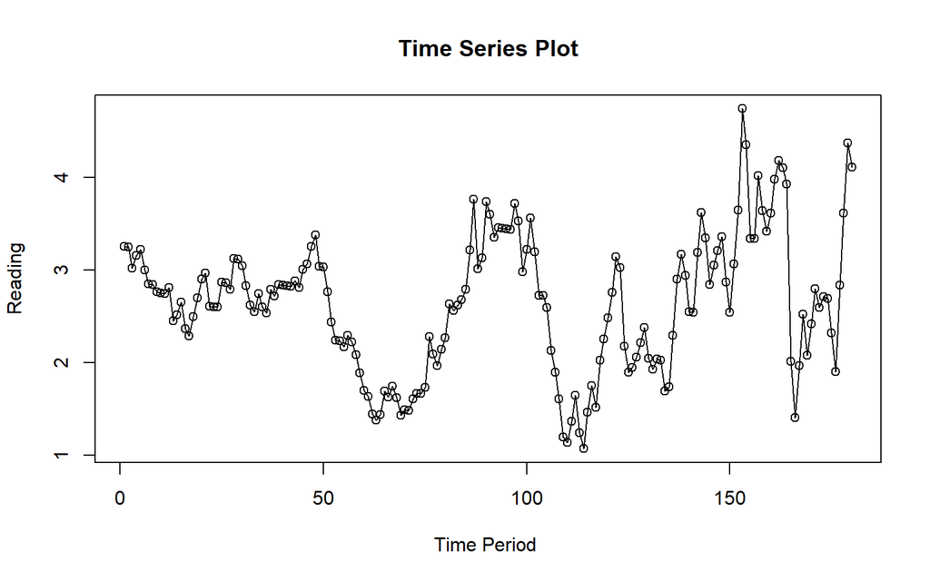

```r
ts.plot(data1.ts, xlab="Time Period ", ylab="Reading",
        main = "Time Series Plot")
points(data1.ts)
```

```r
#menyimpan plot
#dev.copy(png, "plot_data1.png")
#dev.off()
```

## Single Moving Average & Double Moving Average

### Pembagian Data

Pembagian data latih dan data uji dilakukan dengan perbandingan 80% data latih dan 20% data uji.

```r
# hitung jumlah data
n <- nrow(data1)

# tentukan batas 80%
n_train <- floor(0.8 * n)

# bagi data
training_ma <- data1[1:n_train, ]
testing_ma  <- data1[(n_train+1):n, ]

# ubah ke time series
train_ma.ts <- ts(training_ma$CPIAUCSL_PC1)
test_ma.ts  <- ts(testing_ma$CPIAUCSL_PC1)
```

Eksplorasi data dilakukan pada keseluruhan data, data latih serta data uji menggunakan plot data deret waktu.

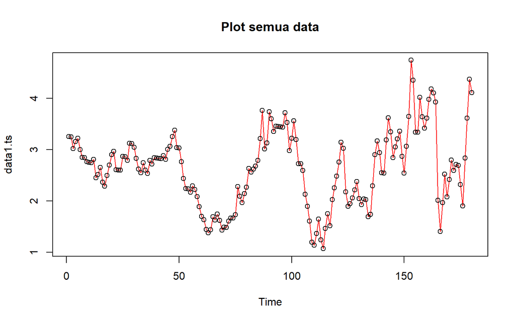

```r
#eksplorasi keseluruhan data
plot(data1.ts, col="red",main="Plot semua data")
points(data1.ts)
```

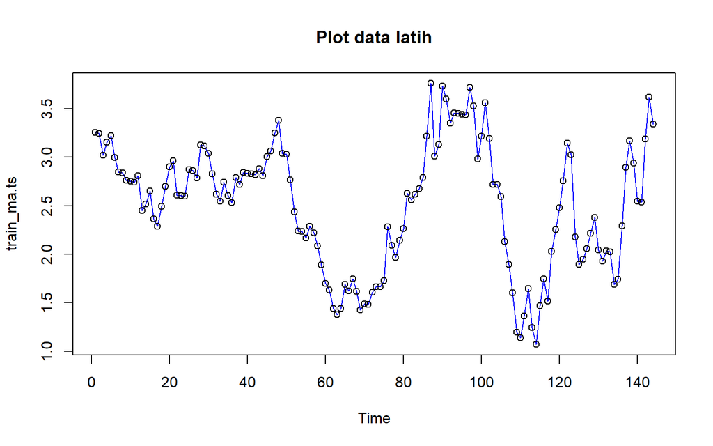

```r
#eksplorasi data latih
plot(train_ma.ts, col="blue",main="Plot data latih")
points(train_ma.ts)
```

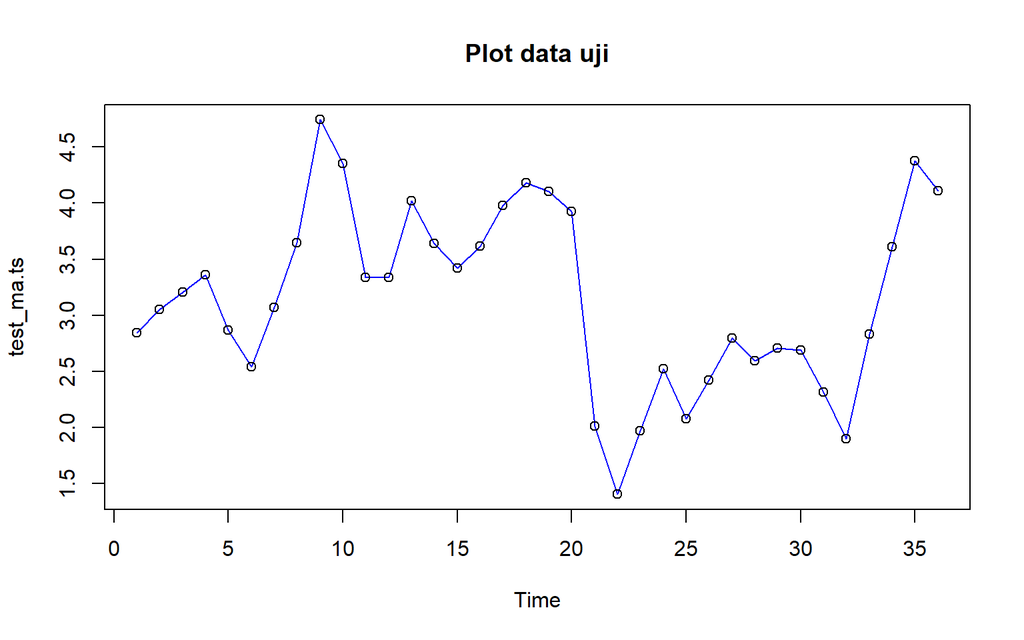

```r
#eksplorasi data uji
plot(test_ma.ts, col="blue",main="Plot data uji")
points(test_ma.ts)
```

Eksplorasi data juga dapat dilakukan menggunakan package `ggplot2` dengan terlebih dahulu memanggil library *package* `ggplot2`.

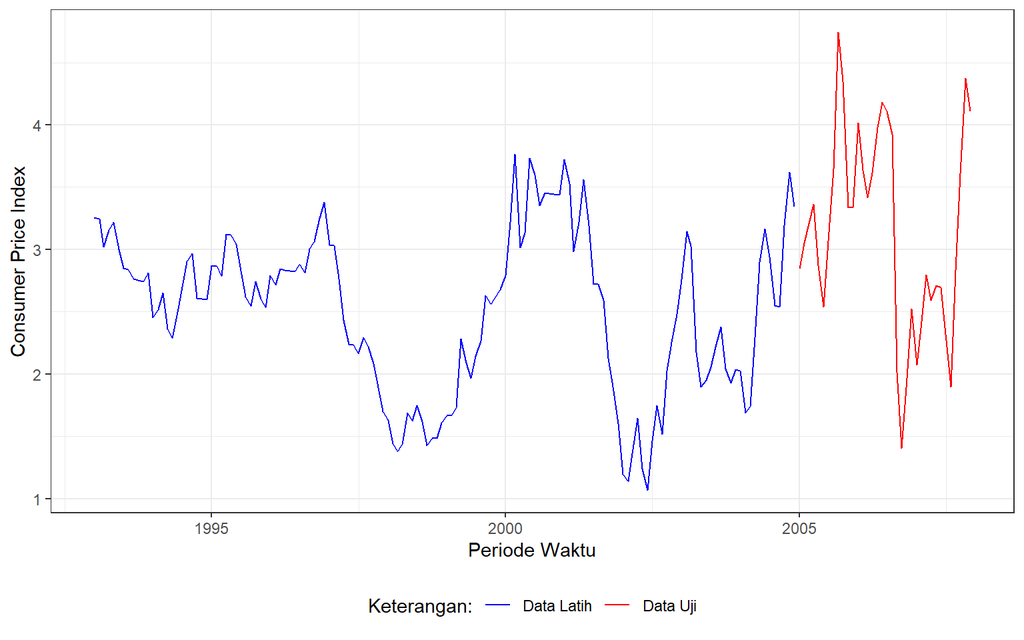

```r
library(ggplot2)
ggplot() +
  geom_line(data = training_ma, aes(x = observation_date
, y = CPIAUCSL_PC1, col = "Data Latih")) +
  geom_line(data = testing_ma, aes(x = observation_date
, y = CPIAUCSL_PC1, col = "Data Uji")) +
  labs(x = "Periode Waktu", y = "Consumer Price Index", color = "Legend") +
   scale_colour_manual(name="Keterangan:", breaks = c("Data Latih", "Data Uji"),
                      values = c("blue", "red")) +
  theme_bw() + theme(legend.position = "bottom",
                     plot.caption = element_text(hjust=0.5, size=12))
```

### Single Moving Average (SMA)

Ide dasar dari Single Moving Average (SMA) adalah data suatu periode dipengaruhi oleh data periode sebelumnya. Metode pemulusan ini cocok digunakan untuk pola data stasioner atau konstan. Prinsip dasar metode pemulusan ini adalah data pemulusan pada periode ke-t merupakan rata rata dari m buah data pada periode ke-t hingga periode ke (t-m+1).

$$S_t = \frac{1}{m} \sum_{i=t-m+1}^{t} X_i$$

Data pemulusan pada periode ke-t selanjutnya digunakan sebagai nilai peramalan pada periode ke t+1.

$$F_t = S_{t-1}, F_{n,h} = S_n$$

Pemulusan menggunakan metode SMA dilakukan dengan fungsi `SMA()`. Dalam hal ini akan dilakukan pemulusan dengan parameter `m=4`.

```r
data.sma<-SMA(train_ma.ts, n=4)
data.sma
```

```
## Time Series:
## Start = 1
## End = 144
## Frequency = 1
##   [1]       NA       NA       NA 3.169085 3.160933 3.098710 3.055602 2.976735
##   [9] 2.862437 2.801045 2.775438 2.767950 2.689695 2.630552 2.607360 2.495718
##  [17] 2.455095 2.449865 2.461660 2.595700 2.764957 2.793730 2.769675 2.693888
##  [25] 2.670210 2.733485 2.779605 2.911505 2.973463 3.018365 3.029108 2.902220
##  [33] 2.758863 2.684290 2.627610 2.606160 2.667533 2.660713 2.720825 2.796080
##  [41] 2.805178 2.831300 2.841160 2.836068 2.880438 2.940530 3.032963 3.174593
##  [49] 3.182985 3.175578 3.053623 2.817503 2.617430 2.417758 2.267843 2.231778
##  [57] 2.227165 2.190265 2.121453 1.973195 1.826125 1.664683 1.536273 1.471610
##  [65] 1.485970 1.531663 1.623893 1.668523 1.603083 1.568858 1.503505 1.501005
##  [73] 1.560973 1.606123 1.667165 1.835718 1.941805 2.016538 2.120590 2.116403
##  [81] 2.251140 2.400375 2.519310 2.622315 2.663063 2.826920 3.112368 3.196733
##  [89] 3.281625 3.410868 3.370153 3.454510 3.535503 3.464350 3.425575 3.446758
##  [97] 3.512933 3.532703 3.417273 3.362833 3.323303 3.239440 3.174195 3.050000
## [105] 2.807273 2.540698 2.333920 2.054468 1.705400 1.457575 1.324698 1.334778
## [113] 1.346010 1.329225 1.354913 1.380780 1.449573 1.689025 1.886003 2.069205
## [121] 2.379570 2.659330 2.852253 2.775968 2.560140 2.260818 2.018405 2.028640
## [129] 2.149683 2.172973 2.141175 2.095958 2.007950 1.919578 1.872505 1.936850
## [137] 2.154718 2.524523 2.824398 2.888110 2.798463 2.804273 2.974783 3.173505
```

Data pemulusan pada periode ke-t selanjutnya digunakan sebagai nilai peramalan pada periode ke t+1 sehingga hasil peramalan 1 periode kedepan adalah sebagai berikut.

```r
data.ramal<-c(NA,data.sma)
data.ramal #forecast 1 periode ke depan
```

```
##   [1]       NA       NA       NA       NA 3.169085 3.160933 3.098710 3.055602
##   [9] 2.976735 2.862437 2.801045 2.775438 2.767950 2.689695 2.630552 2.607360
##  [17] 2.495718 2.455095 2.449865 2.461660 2.595700 2.764957 2.793730 2.769675
##  [25] 2.693888 2.670210 2.733485 2.779605 2.911505 2.973463 3.018365 3.029108
##  [33] 2.902220 2.758863 2.684290 2.627610 2.606160 2.667533 2.660713 2.720825
##  [41] 2.796080 2.805178 2.831300 2.841160 2.836068 2.880438 2.940530 3.032963
##  [49] 3.174593 3.182985 3.175578 3.053623 2.817503 2.617430 2.417758 2.267843
##  [57] 2.231778 2.227165 2.190265 2.121453 1.973195 1.826125 1.664683 1.536273
##  [65] 1.471610 1.485970 1.531663 1.623893 1.668523 1.603083 1.568858 1.503505
##  [73] 1.501005 1.560973 1.606123 1.667165 1.835718 1.941805 2.016538 2.120590
##  [81] 2.116403 2.251140 2.400375 2.519310 2.622315 2.663063 2.826920 3.112368
##  [89] 3.196733 3.281625 3.410868 3.370153 3.454510 3.535503 3.464350 3.425575
##  [97] 3.446758 3.512933 3.532703 3.417273 3.362833 3.323303 3.239440 3.174195
## [105] 3.050000 2.807273 2.540698 2.333920 2.054468 1.705400 1.457575 1.324698
## [113] 1.334778 1.346010 1.329225 1.354913 1.380780 1.449573 1.689025 1.886003
## [121] 2.069205 2.379570 2.659330 2.852253 2.775968 2.560140 2.260818 2.018405
## [129] 2.028640 2.149683 2.172973 2.141175 2.095958 2.007950 1.919578 1.872505
## [137] 1.936850 2.154718 2.524523 2.824398 2.888110 2.798463 2.804273 2.974783
## [145] 3.173505
```

```r
n <- length(data1.ts)
h <- length(test_ma.ts)

data.gab <- cbind(
  aktual = c(as.numeric(data1.ts), rep(NA, h)),

  pemulusan = c(
    as.numeric(data.sma),
    rep(NA, n - length(data.sma) + h)
  ),

  ramalan = c(
    rep(NA, n),
    rep(data.ramal[length(data.ramal)], h)
  )
)

data.gab
```

```
##         aktual pemulusan  ramalan
##   [1,] 3.25380        NA       NA
##   [2,] 3.24675        NA       NA
##   [3,] 3.01941        NA       NA
##   [4,] 3.15638  3.169085       NA
##   [5,] 3.22119  3.160933       NA
##   [6,] 2.99786  3.098710       NA
##   [7,] 2.84698  3.055602       NA
##   [8,] 2.84091  2.976735       NA
##   [9,] 2.76400  2.862437       NA
##  [10,] 2.75229  2.801045       NA
##  [11,] 2.74455  2.775438       NA
##  [12,] 2.81096  2.767950       NA
##  [13,] 2.45098  2.689695       NA
##  [14,] 2.51572  2.630552       NA
```

[output cut: 202 more lines]

Adapun plot data deret waktu dari hasil peramalan yang dilakukan adalah sebagai berikut.

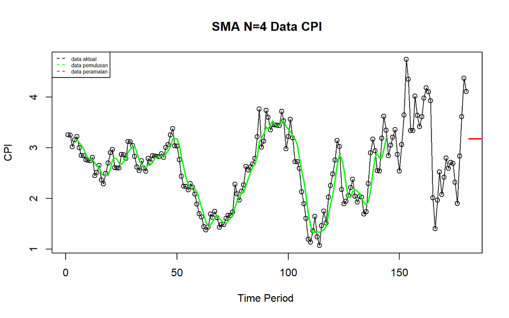

```r
ts.plot(data1.ts, xlab="Time Period ", ylab="CPI", main= "SMA N=4 Data CPI")
points(data1.ts)
lines(data.gab[,2],col="green",lwd=2)
lines(data.gab[,3],col="red",lwd=2)
legend("topleft",c("data aktual","data pemulusan","data peramalan"), lty=8, col=c("black","green","red"), cex=0.5)
```

Selanjutnya perhitungan akurasi dilakukan dengan ukuran akurasi *Sum Squares Error* (SSE), *Mean Square Error* (MSE) dan *Mean Absolute Percentage Error* (MAPE). Perhitungan akurasi dilakukan baik pada data latih maupun pada data uji.

$$SSE = \sum_{t=1}^{n} (y_t - \hat{y}_t)^2$$
$$MSE = \frac{1}{n} \sum_{t=1}^{n} (y_t - \hat{y}_t)^2$$
$$MAPE = \frac{1}{n} \sum_{t=1}^{n} \left|\frac{y_t -
\hat{y}_t}{y_t}\right| * 100$$

```r
#Menghitung nilai keakuratan data latih
error_train.sma = train_ma.ts-data.ramal[1:length(train_ma.ts)]

SSE_train.sma = sum(error_train.sma[5:length(train_ma.ts)]^2)
MSE_train.sma = mean(error_train.sma[5:length(train_ma.ts)]^2)
MAPE_train.sma = mean(abs((error_train.sma[5:length(train_ma.ts)]/train_ma.ts[5:length(train_ma.ts)])*100))

akurasi_train.sma <- matrix(c(SSE_train.sma, MSE_train.sma, MAPE_train.sma))
row.names(akurasi_train.sma)<- c("SSE", "MSE", "MAPE")
colnames(akurasi_train.sma) <- c("Akurasi m = 4")
akurasi_train.sma
```

```
##      Akurasi m = 4
## SSE     18.0103080
## MSE      0.1286451
## MAPE    12.1568829
```

```r
#Menghitung nilai keakuratan data uji
ramalan_test.sma <- rep(data.ramal[length(data.ramal)], length(test_ma.ts))
error_test.sma = test_ma.ts-ramalan_test.sma

SSE_test.sma = sum(error_test.sma^2)
MSE_test.sma = mean(error_test.sma^2)
MAPE_test.sma = mean(abs((error_test.sma/test_ma.ts*100)))

akurasi_test.sma <- matrix(c(SSE_test.sma, MSE_test.sma, MAPE_test.sma))
row.names(akurasi_test.sma)<- c("SSE", "MSE", "MAPE")
colnames(akurasi_test.sma) <- c("Akurasi m = 4")
akurasi_test.sma
```

```
##      Akurasi m = 4
## SSE     23.0892254
## MSE      0.6413674
## MAPE    24.6376716
```

### Double Moving Average (DMA)

Metode pemulusan Double Moving Average (DMA) pada dasarnya mirip dengan SMA. Namun demikian, metode ini lebih cocok digunakan untuk pola data trend. Proses pemulusan dengan rata rata dalam metode ini dilakukan sebanyak 2 kali.

- **Tahap I:**

$$S_{1,t} = \frac{1}{m} \sum_{i=t-m+1}^{t} X_i$$

- **Tahap II:**

$$S_{2,t} = \frac{1}{m} \sum_{i=t-m+1}^{t} S_{1,i}$$

Forecast $h$ langkah ke depan dihitung dengan:

$$F_{2,t,t+h} = A_t + B_t \,(h)$$

dengan komponen level ($A_t$) dan tren ($B_t$):

$$A_t = 2S_{1,t} - S_{2,t}
\qquad\text{dan}\qquad
B_t = \frac{2}{m-1}\,\big(S_{1,t} - S_{2,t}\big)$$

```r
dma <- SMA(data.sma, n = 4)
At <- 2*data.sma - dma
Bt <- 2/(4-1)*(data.sma - dma)
data.dma<- At+Bt
data.ramal2<- c(NA, data.dma)

t = 1:h
f = c()

for (i in t) {
  f[i] = At[length(At)] + Bt[length(Bt)]*(i)
}

data.gab2 <- cbind(aktual = c(data1.ts),
                   pemulusan1 = c(data.sma,rep(NA,h)),
                   pemulusan2 = c(dma, rep(NA,h)),
                   At = c(At, rep(NA,h)),
                   Bt = c(Bt,rep(NA,h)),
                   ramalan = c(data.ramal2, f[-1]))
data.gab2
```

```
##         aktual pemulusan1 pemulusan2       At           Bt   ramalan
##   [1,] 3.25380         NA         NA       NA           NA        NA
##   [2,] 3.24675         NA         NA       NA           NA        NA
##   [3,] 3.01941         NA         NA       NA           NA        NA
##   [4,] 3.15638   3.169085         NA       NA           NA        NA
##   [5,] 3.22119   3.160933         NA       NA           NA        NA
##   [6,] 2.99786   3.098710         NA       NA           NA        NA
##   [7,] 2.84698   3.055602   3.121082 2.990123 -0.043653333        NA
##   [8,] 2.84091   2.976735   3.072995 2.880475 -0.064173333 2.9464692
##   [9,] 2.76400   2.862437   2.998371 2.726504 -0.090622500 2.8163017
##  [10,] 2.75229   2.801045   2.923955 2.678135 -0.081940000 2.6358813
##  [11,] 2.74455   2.775438   2.853914 2.696961 -0.052317500 2.5961950
##  [12,] 2.81096   2.767950   2.801718 2.734182 -0.022511667 2.6446438
##  [13,] 2.45098   2.689695   2.758532 2.620858 -0.045891250 2.7116708
##  [14,] 2.51572   2.630552   2.715909 2.545196 -0.056904167 2.5749669
```

[output cut: 166 more lines]

Hasil pemulusan menggunakan metode DMA divisualisasikan sebagai berikut

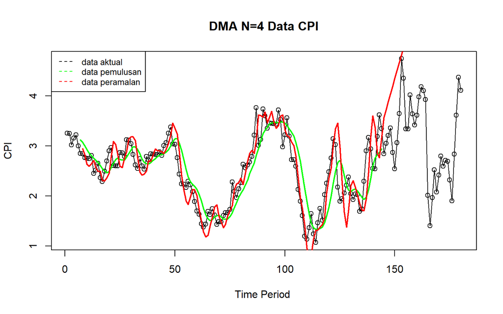

```r
ts.plot(data1.ts, xlab="Time Period ", ylab="CPI", main= "DMA N=4 Data CPI")
points(data1.ts)
lines(data.gab2[,3],col="green",lwd=2)
lines(data.gab2[,6],col="red",lwd=2)
legend("topleft",c("data aktual","data pemulusan","data peramalan"), lty=8, col=c("black","green","red"), cex=0.8)
```

Selanjutnya perhitungan akurasi dilakukan baik pada data latih maupun data uji. Perhitungan akurasi dilakukan dengan ukuran akurasi SSE, MSE dan MAPE.

```r
#Menghitung nilai keakuratan data latih
error_train.dma = train_ma.ts-data.ramal2[1:length(train_ma.ts)]

SSE_train.dma = sum(error_train.dma[8:length(train_ma.ts)]^2)
MSE_train.dma = mean(error_train.dma[8:length(train_ma.ts)]^2)
MAPE_train.dma = mean(abs((error_train.dma[8:length(train_ma.ts)]/train_ma.ts[8:length(train_ma.ts)])*100))

akurasi_train.dma <- matrix(c(SSE_train.dma, MSE_train.dma, MAPE_train.dma))
row.names(akurasi_train.dma)<- c("SSE", "MSE", "MAPE")
colnames(akurasi_train.dma) <- c("Akurasi m = 4")
akurasi_train.dma
```

```
##      Akurasi m = 4
## SSE      17.564499
## MSE       0.128208
## MAPE     11.539710
```

```r
#Menghitung nilai keakuratan data uji
error_test.dma = test_ma.ts-f[1:length(test_ma.ts)]
SSE_test.dma = sum(error_test.dma^2)
MSE_test.dma = mean(error_test.dma^2)
MAPE_test.dma = mean(abs((error_test.dma/test_ma.ts*100)))

akurasi_test.dma <- matrix(c(SSE_test.dma, MSE_test.dma, MAPE_test.dma))
row.names(akurasi_test.dma)<- c("SSE", "MSE", "MAPE")
colnames(akurasi_test.dma) <- c("Akurasi m = 4")
akurasi_test.dma
```

```
##      Akurasi m = 4
## SSE      498.77503
## MSE       13.85486
## MAPE     120.16080
```

## Single Exponential Smoothing & Double Exponential Smoothing

Metode Exponential Smoothing merupakan metode pemulusan deret waktu dengan memberikan bobot yang menurun secara eksponensial pada data historis, di mana nilai terbaru mendapat bobot lebih besar dibanding nilai yang lebih lama. Metode ini menggunakan satu atau lebih parameter pemulusan yang secara langsung menentukan besar kecilnya bobot setiap pengamatan. Pemilihan parameter yang tepat akan sangat berpengaruh terhadap hasil ramalan. Secara umum, Exponential Smoothing dibedakan menjadi dua jenis, yaitu model tunggal (single) yang digunakan untuk data tanpa tren maupun musiman, serta model ganda (double) yang mampu menangkap adanya tren pada data.

### Pembagian Data

Pembagian data latih dan data uji dilakukan dengan perbandingan 80% data latih dan 20% data uji.

```r
# jumlah baris data
n <- nrow(data1)

# hitung batas 80%
n_train <- floor(0.8 * n)

# bagi data
training <- data1[1:n_train, ]
testing  <- data1[(n_train+1):n, ]

# ubah ke time series
train.ts <- ts(training$CPIAUCSL_PC1)
test.ts  <- ts(testing$CPIAUCSL_PC1)

# jumlah periode yang akan diramalkan mengikuti jumlah data uji
n_test <- nrow(testing)
```

### Eksplorasi

Eksplorasi dilakukan dengan membuat plot data deret waktu untuk keseluruhan data, data latih, dan data uji.

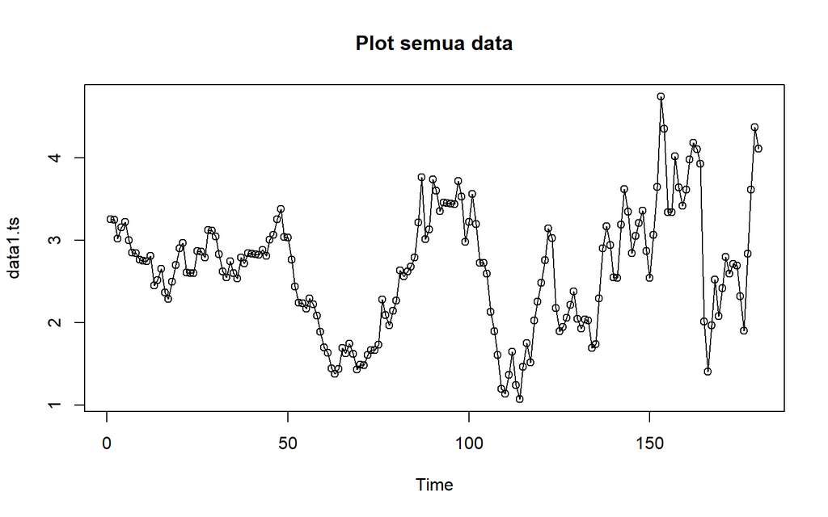

```r
#eksplorasi data
plot(data1.ts, col="black",main="Plot semua data")
points(data1.ts)
```

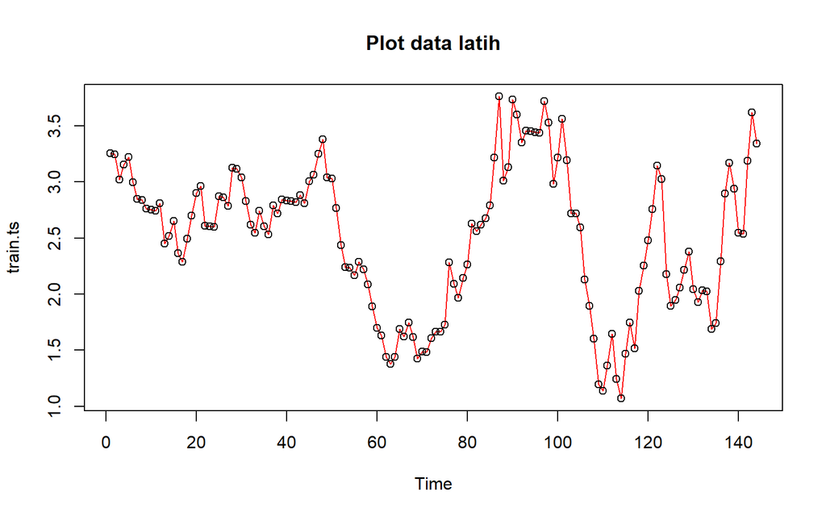

```r
plot(train.ts, col="red",main="Plot data latih")
points(train.ts)
```

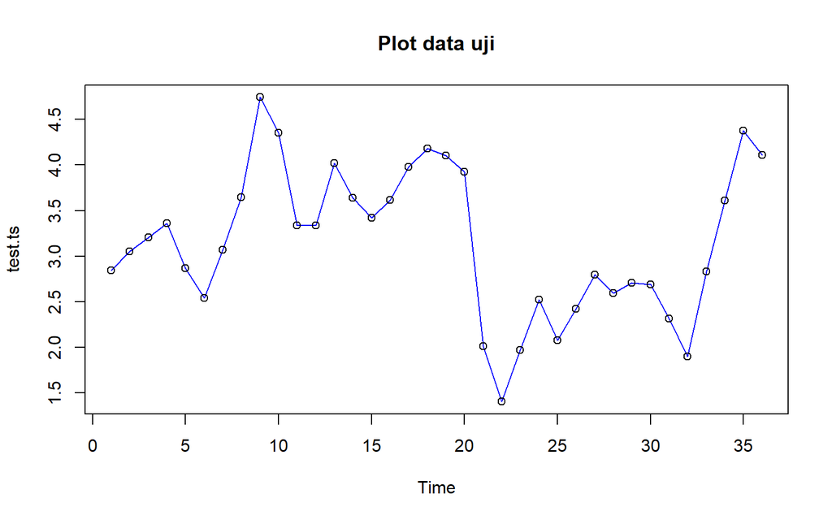

```r
plot(test.ts, col="blue",main="Plot data uji")
points(test.ts)
```

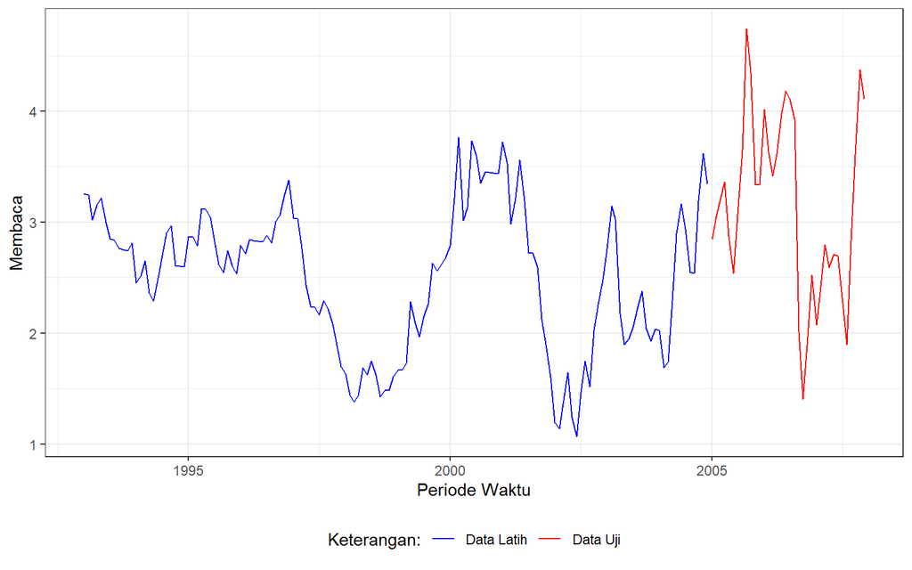

```r
#Eksplorasi dengan GGPLOT
library(ggplot2)
ggplot() +
  geom_line(data = training, aes(x = observation_date, y = CPIAUCSL_PC1, col = "Data Latih")) +
  geom_line(data = testing, aes(x = observation_date, y = CPIAUCSL_PC1, col = "Data Uji")) +
  labs(x = "Periode Waktu", y = "Membaca", color = "Legend") +
  scale_colour_manual(name="Keterangan:", breaks = c("Data Latih", "Data Uji"),
                      values = c("blue", "red")) +
  theme_bw() + theme(legend.position = "bottom",
                     plot.caption = element_text(hjust=0.5, size=12))
```

### Single Exponential Smoothing

Single Exponential Smoothing (SES) adalah metode peramalan deret waktu yang dikembangkan untuk mengatasi kelemahan Moving Average. Jika pada Moving Average setiap data periode sebelumnya dianggap memiliki bobot yang sama, maka SES memberikan bobot yang semakin mengecil secara eksponensial terhadap data lama, sehingga data terbaru diberi bobot lebih besar.

Single Exponential Smoothing merupakan metode pemulusan yang tepat digunakan untuk data dengan pola stasioner atau konstan.

Nilai pemulusan pada periode ke-t didapat dari persamaan:

$$\tilde{y}_T=\lambda
y_t+(1-\lambda)\tilde{y}_{T-1}$$

Nilai parameter $\lambda$ adalah nilai antara 0 dan 1.

Nilai pemulusan periode ke-t bertindak sebagai nilai ramalan pada periode ke-$(T+\tau)$.

$$\tilde{y}_{T+\tau}(T)=\tilde{y}_T$$

Pemulusan dengan metode SES dapat dilakukan dengan dua fungsi dari *packages* berbeda, yaitu (1) fungsi `ses()` dari *packages* `forecast` dan (2) fungsi `HoltWinters` dari *packages* `stats` .

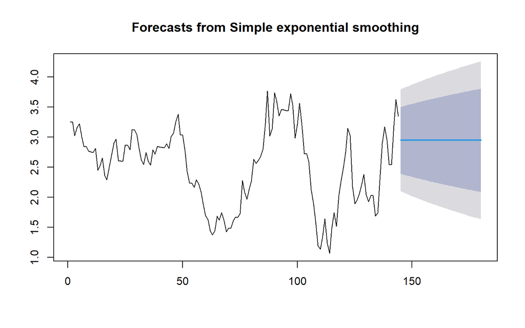

```r
#Cara 1 (fungsi ses)
ses.1 <- ses(train.ts, h = n_test, alpha = 0.2)
plot(ses.1)
```

```r
ses.1
```

```
##     Point Forecast    Lo 80    Hi 80    Lo 95    Hi 95
## 145       2.945689 2.392685 3.498693 2.099942 3.791435
## 146       2.945689 2.381733 3.509644 2.083193 3.808184
## 147       2.945689 2.370990 3.520387 2.066763 3.824614
## 148       2.945689 2.360444 3.530933 2.050635 3.840743
## 149       2.945689 2.350085 3.541292 2.034792 3.856585
## 150       2.945689 2.339903 3.551474 2.019220 3.872157
## 151       2.945689 2.329890 3.561488 2.003905 3.887472
## 152       2.945689 2.320036 3.571341 1.988836 3.902542
## 153       2.945689 2.310336 3.581042 1.974000 3.917377
## 154       2.945689 2.300781 3.590596 1.959387 3.931990
## 155       2.945689 2.291366 3.600012 1.944988 3.946389
## 156       2.945689 2.282084 3.609293 1.930793 3.960584
## 157       2.945689 2.272930 3.618447 1.916794 3.974584
## 158       2.945689 2.263900 3.627478 1.902982 3.988395
```

[output cut: 22 more lines]

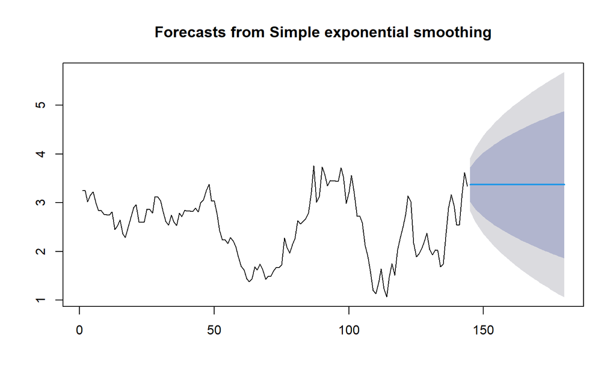

```r
ses.2<- ses(train.ts, h = n_test, alpha = 0.7)
plot(ses.2)
```

```r
ses.2
```

```
##     Point Forecast    Lo 80    Hi 80    Lo 95    Hi 95
## 145       3.370826 3.015835 3.725817 2.827914 3.913738
## 146       3.370826 2.937504 3.804148 2.708118 4.033534
## 147       3.370826 2.871309 3.870342 2.606881 4.134770
## 148       3.370826 2.812914 3.928738 2.517573 4.224079
## 149       3.370826 2.760076 3.981575 2.436765 4.304887
## 150       3.370826 2.711460 4.030192 2.362412 4.379240
## 151       3.370826 2.666189 4.075463 2.293177 4.448475
## 152       3.370826 2.623656 4.117995 2.228129 4.513523
## 153       3.370826 2.583418 4.158234 2.166589 4.575062
## 154       3.370826 2.545138 4.196514 2.108045 4.633606
## 155       3.370826 2.508556 4.233096 2.052098 4.689554
## 156       3.370826 2.473464 4.268188 1.998429 4.743223
## 157       3.370826 2.439693 4.301958 1.946782 4.794870
## 158       3.370826 2.407106 4.334546 1.896943 4.844709
```

[output cut: 22 more lines]

Pada fungsi `ses()` , terdapat beberapa argumen yang umum digunakan, yaitu

- `y` : nilai data deret waktu
- `alpha` : parameter pemulusan utama (0–1), mengatur bobot data terbaru vs data lama.
- `beta` : parameter pemulusan tren.
- `gamma` : parameter pemulusan musiman.
- `h` : jumlah periode ke depan yang ingin diramalkan (forecast horizon).

Untuk mendapatkan gambar hasil pemulusan pada data latih dengan fungsi `ses()` , perlu digunakan fungsi `autoplot()` dan `autolayer()` dari *library packages* `ggplot2` .

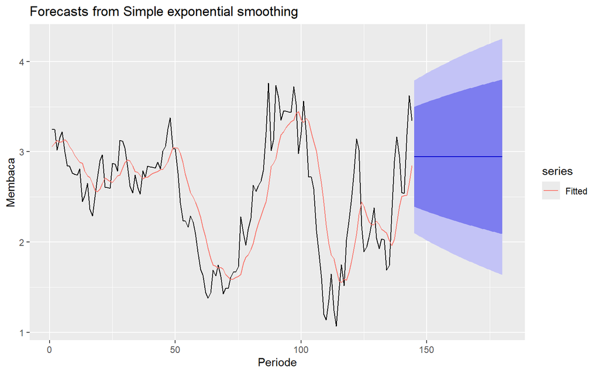

```r
autoplot(ses.1) +
  autolayer(fitted(ses.1), series="Fitted") +
  ylab("Membaca") + xlab("Periode")
```

Selanjutnya akan digunakan fungsi `HoltWinters()` dengan nilai inisialisasi parameter dan panjang periode peramalan yang sama dengan fungsi `ses()` .

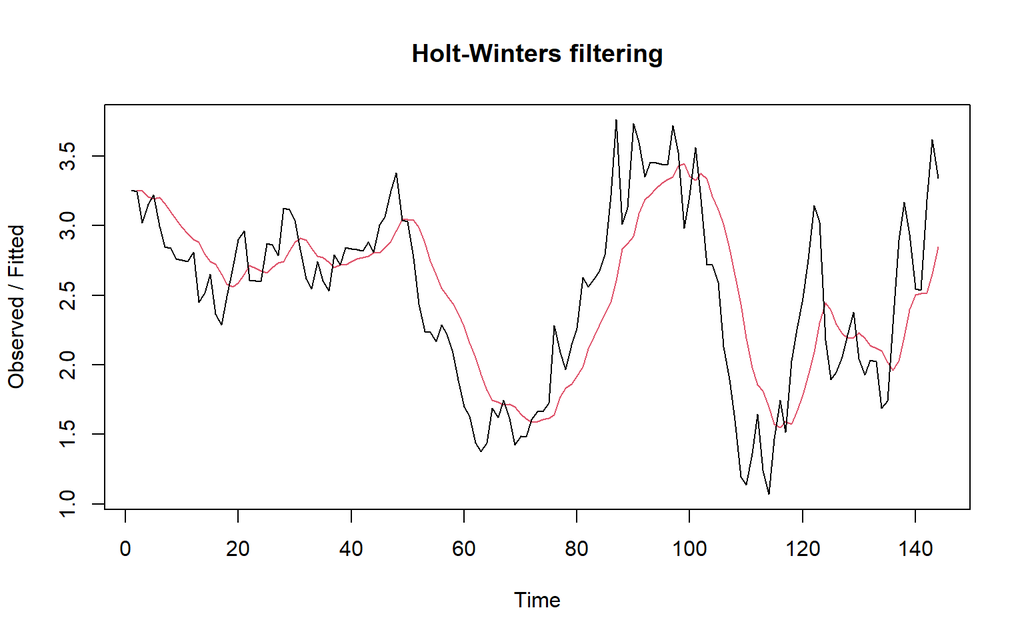

```r
#Cara 2 (fungsi Holtwinter)
ses1<- HoltWinters(train.ts, gamma = FALSE, beta = FALSE, alpha = 0.2)
plot(ses1)
```

```r
#ramalan
ramalan1<- forecast(ses1, h=n_test)
ramalan1
```

```
##     Point Forecast    Lo 80    Hi 80    Lo 95    Hi 95
## 145       2.945689 2.391748 3.499629 2.098509 3.792868
## 146       2.945689 2.380778 3.510600 2.081732 3.809645
## 147       2.945689 2.370016 3.521361 2.065274 3.826103
## 148       2.945689 2.359453 3.531924 2.049118 3.842259
## 149       2.945689 2.349076 3.542301 2.033249 3.858129
## 150       2.945689 2.338877 3.552500 2.017650 3.873727
## 151       2.945689 2.328846 3.562531 2.002310 3.889068
## 152       2.945689 2.318976 3.572401 1.987215 3.904163
## 153       2.945689 2.309259 3.582118 1.972354 3.919024
## 154       2.945689 2.299688 3.591689 1.957716 3.933661
## 155       2.945689 2.290257 3.601120 1.943293 3.948085
## 156       2.945689 2.280960 3.610418 1.929073 3.962304
## 157       2.945689 2.271791 3.619587 1.915050 3.976327
## 158       2.945689 2.262745 3.628633 1.901216 3.990162
```

[output cut: 22 more lines]

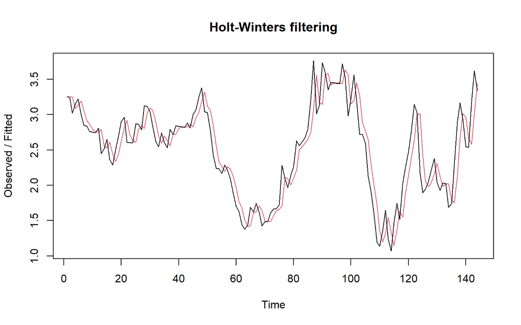

```r
ses2<- HoltWinters(train.ts, gamma = FALSE, beta = FALSE, alpha = 0.7)
plot(ses2)
```

```r
#ramalan
ramalan2<- forecast(ses2, h=n_test)
ramalan2
```

```
##     Point Forecast    Lo 80    Hi 80    Lo 95    Hi 95
## 145       3.370826 3.015832 3.725820 2.827909 3.913743
## 146       3.370826 2.937500 3.804152 2.708112 4.033540
## 147       3.370826 2.871305 3.870347 2.606874 4.134778
## 148       3.370826 2.812909 3.928743 2.517565 4.224087
## 149       3.370826 2.760071 3.981581 2.436757 4.304895
## 150       3.370826 2.711453 4.030198 2.362403 4.379249
## 151       3.370826 2.666183 4.075469 2.293167 4.448485
## 152       3.370826 2.623650 4.118002 2.228118 4.513534
## 153       3.370826 2.583411 4.158241 2.166578 4.575074
## 154       3.370826 2.545130 4.196521 2.108034 4.633618
## 155       3.370826 2.508548 4.233104 2.052086 4.689566
## 156       3.370826 2.473456 4.268196 1.998416 4.743235
## 157       3.370826 2.439685 4.301967 1.946769 4.794883
## 158       3.370826 2.407097 4.334555 1.896929 4.844722
```

[output cut: 22 more lines]

Fungsi `HoltWinters` memiliki argumen yang sama dengan fungsi `ses()` . Argumen-argumen kedua fungsi dapat dilihat lebih lanjut dengan `?ses()` atau `?HoltWinters` .

Nilai parameter $\alpha$ dari kedua fungsi dapat dioptimalkan menyesuaikan dari *error*-nya paling minimumnya. Caranya adalah dengan membuat parameter $\alpha =$ `NULL` .

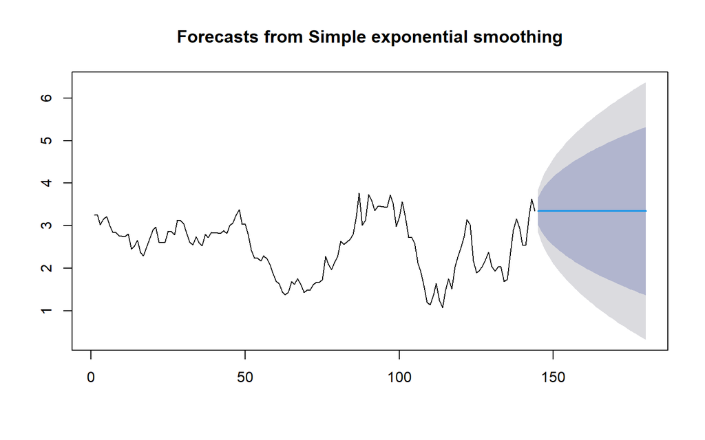

```r
#SES
ses.opt <- ses(train.ts, h = n_test, alpha = NULL)
plot(ses.opt)
```

```r
ses.opt
```

```
##     Point Forecast    Lo 80    Hi 80     Lo 95    Hi 95
## 145       3.342348 3.012358 3.672338 2.8376713 3.847025
## 146       3.342348 2.875695 3.809001 2.6286631 4.056033
## 147       3.342348 2.770826 3.913870 2.4682807 4.216415
## 148       3.342348 2.682417 4.002279 2.3330704 4.351625
## 149       3.342348 2.604526 4.080170 2.2139470 4.470749
## 150       3.342348 2.534107 4.150588 2.1062508 4.578445
## 151       3.342348 2.469351 4.215345 2.0072136 4.677482
## 152       3.342348 2.409076 4.275620 1.9150318 4.769664
## 153       3.342348 2.352465 4.332231 1.8284527 4.856243
## 154       3.342348 2.298921 4.385775 1.7465640 4.938132
## 155       3.342348 2.247993 4.436702 1.6686772 5.016019
## 156       3.342348 2.199333 4.485363 1.5942571 5.090439
## 157       3.342348 2.152661 4.532035 1.5228785 5.161817
## 158       3.342348 2.107752 4.576944 1.4541963 5.230500
```

[output cut: 22 more lines]

```r
#Lamda Optimum Holt Winter
HWopt<- HoltWinters(train.ts, gamma = FALSE, beta = FALSE,alpha = NULL)
HWopt
```

```
## Holt-Winters exponential smoothing without trend and without seasonal component.
##
## Call:
## HoltWinters(x = train.ts, alpha = NULL, beta = FALSE, gamma = FALSE)
##
## Smoothing parameters:
##  alpha: 0.999928
##  beta : FALSE
##  gamma: FALSE
##
## Coefficients:
##      [,1]
## a 3.34234
```

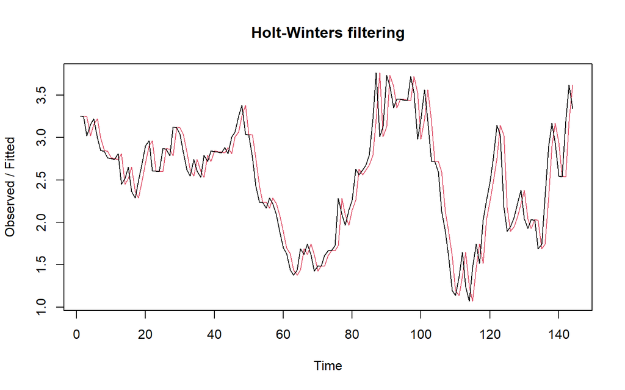

```r
plot(HWopt)
```

```r
#ramalan
ramalanopt<- forecast(HWopt, h=n_test)
ramalanopt
```

```
##     Point Forecast    Lo 80    Hi 80     Lo 95    Hi 95
## 145        3.34234 3.012477 3.672203 2.8378583 3.846822
## 146        3.34234 2.875860 3.808820 2.6289208 4.055759
## 147        3.34234 2.771028 3.913652 2.4685940 4.216086
## 148        3.34234 2.682650 4.002030 2.3334311 4.351249
## 149        3.34234 2.604787 4.079893 2.2143496 4.470331
## 150        3.34234 2.534393 4.150287 2.1066914 4.577989
## 151        3.34234 2.469659 4.215021 2.0076892 4.676991
## 152        3.34234 2.409406 4.275274 1.9155401 4.769140
## 153        3.34234 2.352815 4.331865 1.8289917 4.855689
## 154        3.34234 2.299290 4.385391 1.7471321 4.937548
## 155        3.34234 2.248380 4.436300 1.6692729 5.015407
## 156        3.34234 2.199737 4.484943 1.5948794 5.089801
## 157        3.34234 2.153082 4.531599 1.5235261 5.161154
## 158        3.34234 2.108189 4.576492 1.4548684 5.229812
```

[output cut: 22 more lines]

Setelah dilakukan peramalan, akan dilakukan perhitungan keakuratan hasil peramalan. Perhitungan akurasi ini dilakukan baik pada data latih dan data uji.

#### Akurasi Data Latih

Perhitungan akurasi data dapat dilakukan dengan cara langsung maupun manual. Secara langsung, nilai akurasi dapat diambil dari objek yang tersimpan pada hasil SES, yaitu *sum of squared errors* (SSE). Nilai akurasi lain dapat dihitung pula dari nilai SSE tersebut.

```r
#Keakuratan Metode
#Pada data training

# SES dengan alpha = 0.2
SSE1<-ses1$SSE
MSE1<-ses1$SSE/length(train.ts)
RMSE1<-sqrt(MSE1)

akurasi1 <- matrix(c(SSE1,MSE1,RMSE1))
row.names(akurasi1)<- c("SSE", "MSE", "RMSE")
colnames(akurasi1) <- c("Akurasi lamda=0.2")
akurasi1
```

```
##      Akurasi lamda=0.2
## SSE         26.5469418
## MSE          0.1843538
## RMSE         0.4293644
```

```r
# SES dengan alpha = 0.7
SSE2<-ses2$SSE
MSE2<-ses2$SSE/length(train.ts)
RMSE2<-sqrt(MSE2)

akurasi2 <- matrix(c(SSE2,MSE2,RMSE2))
row.names(akurasi2)<- c("SSE", "MSE", "RMSE")
colnames(akurasi2) <- c("Akurasi lamda=0.7")
akurasi2
```

```
##      Akurasi lamda=0.7
## SSE        10.89598437
## MSE         0.07566656
## RMSE        0.27507555
```

```r
#Cara Manual
# Alpha = 0.2
fitted1<-ramalan1$fitted
sisaan1<-ramalan1$residuals
head(sisaan1)
```

```
## Time Series:
## Start = 1
## End = 6
## Frequency = 1
## [1]         NA -0.0070500 -0.2329800 -0.0494140  0.0252788 -0.2031070
```

```r
resid1<-training$CPIAUCSL_PC1-ramalan1$fitted
head(resid1)
```

```
## Time Series:
## Start = 1
## End = 6
## Frequency = 1
## [1]         NA -0.0070500 -0.2329800 -0.0494140  0.0252788 -0.2031070
```

```r
SSE.1=sum(sisaan1[2:length(train.ts)]^2)
SSE.1
```

```
## [1] 26.54694
```

```r
MSE.1 = SSE.1/length(train.ts)
MSE.1
```

```
## [1] 0.1843538
```

```r
MAPE.1 = sum(abs(sisaan1[2:length(train.ts)]/train.ts[2:length(train.ts)])*
               100)/length(train.ts)
MAPE.1
```

```
## [1] 14.86813
```

```r
akurasi.1 <- matrix(c(SSE.1,MSE.1,MAPE.1))
row.names(akurasi.1)<- c("SSE", "MSE", "MAPE")
colnames(akurasi.1) <- c("Akurasi lamda=0.2")
akurasi.1
```

```
##      Akurasi lamda=0.2
## SSE         26.5469418
## MSE          0.1843538
## MAPE        14.8681330
```

```r
# Alpha = 0.7
fitted2<-ramalan2$fitted
sisaan2<-ramalan2$residuals
head(sisaan2)
```

```
## Time Series:
## Start = 1
## End = 6
## Frequency = 1
## [1]          NA -0.00705000 -0.22945500  0.06813350  0.08525005 -0.19775498
```

```r
resid2<-training$CPIAUCSL_PC1-ramalan2$fitted
head(resid2)
```

```
## Time Series:
## Start = 1
## End = 6
## Frequency = 1
## [1]          NA -0.00705000 -0.22945500  0.06813350  0.08525005 -0.19775498
```

```r
SSE.2=sum(sisaan2[2:length(train.ts)]^2)
SSE.2
```

```
## [1] 10.89598
```

```r
MSE.2 = SSE.2/length(train.ts)
MSE.2
```

```
## [1] 0.07566656
```

```r
MAPE.2 = sum(abs(sisaan2[2:length(train.ts)]/train.ts[2:length(train.ts)])*
               100)/length(train.ts)
MAPE.2
```

```
## [1] 8.961906
```

```r
akurasi.2 <- matrix(c(SSE.2,MSE.2,MAPE.2))
row.names(akurasi.2)<- c("SSE", "MSE", "MAPE")
colnames(akurasi.2) <- c("Akurasi lamda=0.7")
akurasi.2
```

```
##      Akurasi lamda=0.7
## SSE        10.89598437
## MSE         0.07566656
## MAPE        8.96190648
```

#### Akurasi Data Uji

Akurasi data uji dapat dihitung dengan cara yang hampir sama dengan perhitungan akurasi data latih.

```r
# jumlah observasi uji
n_test <- nrow(testing)

# error (ramalan - aktual), samakan panjang dan tipe numeric
e1   <- as.numeric(ramalan1$mean)[1:n_test] - as.numeric(testing$CPIAUCSL_PC1)
e2   <- as.numeric(ramalan2$mean)[1:n_test] - as.numeric(testing$CPIAUCSL_PC1)
eopt <- as.numeric(ramalanopt$mean)[1:n_test] - as.numeric(testing$CPIAUCSL_PC1)

# SSE / MSE / RMSE untuk masing-masing model (abaikan NA)
SSEtesting1  <- sum(e1^2,  na.rm = TRUE)
MSEtesting1  <- mean(e1^2, na.rm = TRUE)
RMSEtesting1 <- sqrt(MSEtesting1)

SSEtesting2  <- sum(e2^2,  na.rm = TRUE)
MSEtesting2  <- mean(e2^2, na.rm = TRUE)
RMSEtesting2 <- sqrt(MSEtesting2)

SSEtestingopt  <- sum(eopt^2,  na.rm = TRUE)
MSEtestingopt  <- mean(eopt^2, na.rm = TRUE)
RMSEtestingopt <- sqrt(MSEtestingopt)

# Tabel ringkas
akurasitesting_SSE <- matrix(c(SSEtesting1, SSEtesting2, SSEtestingopt),
                             nrow = 3,
                             dimnames = list(c("SSE1","SSE2","SSEopt"), "Nilai"))
akurasitesting_MSE <- matrix(c(MSEtesting1, MSEtesting2, MSEtestingopt),
                             nrow = 3,
                             dimnames = list(c("MSE1","MSE2","MSEopt"), "Nilai"))
akurasitesting_RMSE <- matrix(c(RMSEtesting1, RMSEtesting2, RMSEtestingopt),
                              nrow = 3,
                              dimnames = list(c("RMSE1","RMSE2","RMSEopt"), "Nilai"))

akurasitesting_SSE
```

```
##           Nilai
## SSE1   24.65494
## SSE2   24.75308
## SSEopt 24.33974
```

```r
akurasitesting_MSE
```

```
##            Nilai
## MSE1   0.6848595
## MSE2   0.6875856
## MSEopt 0.6761040
```

```r
akurasitesting_RMSE
```

```
##             Nilai
## RMSE1   0.8275624
## RMSE2   0.8292078
## RMSEopt 0.8222554
```

Selain dengan cara di atas, perhitungan nilai akurasi dapat menggunakan fungsi `accuracy()` dari *package* `forecast` . Penggunaannya yaitu dengan menuliskan `accuracy(hasil ramalan, kondisi aktual)` . Contohnya adalah sebagai berikut.

```r
accuracy(ramalan1, testing$CPIAUCSL_PC1)
```

```
##                       ME      RMSE       MAE       MPE     MAPE     MASE
## Training set -0.01077312 0.4308630 0.3328837 -3.768588 14.97211 1.716493
## Test set      0.20936247 0.8275624 0.6885718 -0.670659 23.28436 3.550576
##                   ACF1
## Training set 0.7994851
## Test set            NA
```

```r
accuracy(ramalan2, testing$CPIAUCSL_PC1)
```

```
##                       ME      RMSE       MAE         MPE      MAPE     MASE
## Training set  0.00116909 0.2760357 0.2093873  -0.9007547  9.024577 1.079692
## Test set     -0.21577480 0.8292078 0.6890585 -15.1999775 26.576024 3.553085
##                   ACF1
## Training set 0.3775314
## Test set            NA
```

```r
accuracy(ramalanopt, testing$CPIAUCSL_PC1)
```

```
##                         ME      RMSE       MAE        MPE      MAPE     MASE
## Training set  0.0006192062 0.2564926 0.1939348  -0.589385  8.259848 1.000012
## Test set     -0.1872890046 0.8222554 0.6838089 -14.226459 26.195787 3.526016
##                   ACF1
## Training set 0.1684108
## Test set            NA
```

### *Double Exponential Smoothing* (DES)

Metode pemulusan *Double Exponential Smoothing* (DES) digunakan untuk data yang memiliki pola tren. Metode DES adalah metode semacam SES, hanya saja dilakukan dua kali, yaitu pertama untuk tahapan ‘level’ dan kedua untuk tahapan ‘tren’. Pemulusan menggunakan metode ini akan menghasilkan peramalan tidak konstan untuk periode berikutnya.

Pemulusan dengan metode DES kali ini akan menggunakan fungsi `HoltWinters()` . Jika sebelumnya nilai argumen `beta` dibuat `FALSE` , kali ini argumen tersebut akan diinisialisasi bersamaan dengan nilai `alpha` .

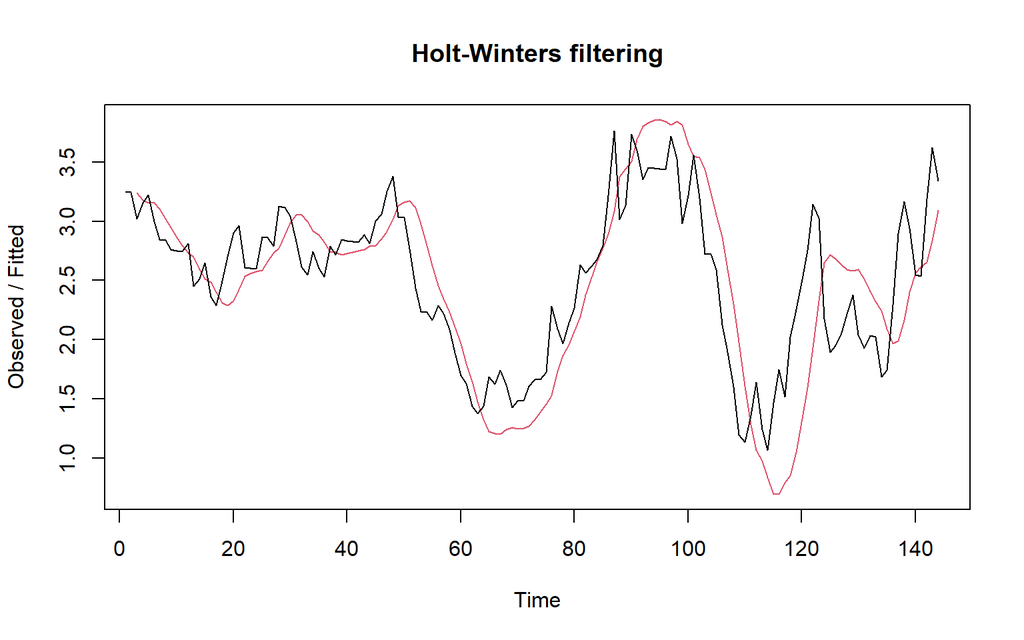

```r
#Lamda=0.2 dan gamma=0.2
des.1<- HoltWinters(train.ts, gamma = FALSE, beta = 0.2, alpha = 0.2)
plot(des.1)
```

```r
#ramalan
ramalandes1<- forecast(des.1, h=n_test)
ramalandes1
```

```
##     Point Forecast    Lo 80     Hi 80    Lo 95     Hi 95
## 145       3.260329 2.672948  3.847710 2.362008  4.158650
## 146       3.375224 2.771164  3.979285 2.451394  4.299055
## 147       3.490120 2.864070  4.116169 2.532659  4.447580
## 148       3.605015 2.951357  4.258672 2.605332  4.604697
## 149       3.719910 3.032901  4.406919 2.669220  4.770600
## 150       3.834805 3.108731  4.560880 2.724370  4.945241
## 151       3.949701 3.179000  4.720401 2.771015  5.128386
## 152       4.064596 3.243943  4.885249 2.809515  5.319676
## 153       4.179491 3.303841  5.055141 2.840299  5.518683
## 154       4.294386 3.358993  5.229780 2.863826  5.724947
## 155       4.409281 3.409698  5.408865 2.880551  5.938012
## 156       4.524177 3.456242  5.592112 2.890911  6.157442
## 157       4.639072 3.498888  5.779256 2.895310  6.382834
## 158       4.753967 3.537876  5.970058 2.894117  6.613818
```

[output cut: 22 more lines]

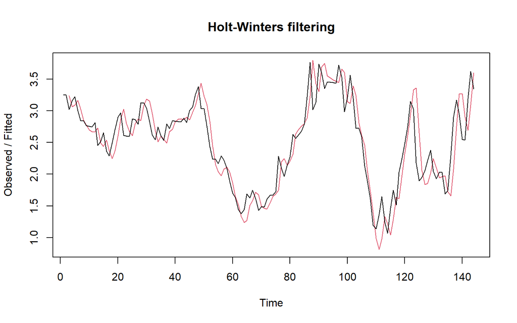

```r
#Lamda=0.6 dan gamma=0.3
des.2<- HoltWinters(train.ts, gamma = FALSE, beta = 0.3, alpha = 0.6)
plot(des.2)
```

```r
#ramalan
ramalandes2<- forecast(des.2, h=n_test)
ramalandes2
```

```
##     Point Forecast       Lo 80     Hi 80       Lo 95     Hi 95
## 145       3.590157  3.20957291  3.970742  3.00810360  4.172211
## 146       3.735330  3.25266263  4.217998  2.99715379  4.473507
## 147       3.880503  3.27514630  4.485860  2.95468975  4.806317
## 148       4.025676  3.28089614  4.770456  2.88663353  5.164718
## 149       4.170849  3.27247567  5.069222  2.79690568  5.544792
## 150       4.316022  3.25160878  5.380434  2.68814268  5.943901
## 151       4.461194  3.21950843  5.702880  2.56219957  6.360189
## 152       4.606367  3.17707072  6.035664  2.42044684  6.792288
## 153       4.751540  3.12498728  6.378093  2.26394226  7.239138
## 154       4.896713  3.06381186  6.729614  2.09353266  7.699893
## 155       5.041886  2.99400114  7.089770  1.90991653  8.173855
## 156       5.187059  2.91594097  7.458176  1.71368396  8.660433
## 157       5.332231  2.82996371  7.834499  1.50534323  9.159119
## 158       5.477404  2.73636015  8.218448  1.28533909  9.669469
```

[output cut: 22 more lines]

Selanjutnya jika ingin membandingkan plot data latih dan data uji adalah sebagai berikut.

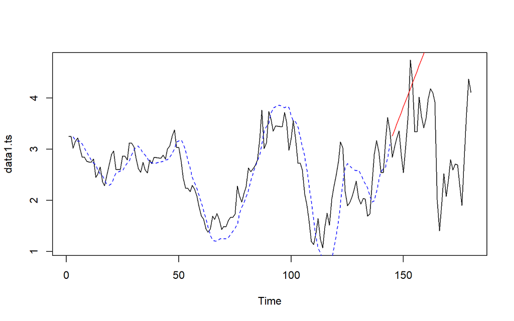

```r
plot(data1.ts)
lines(des.1$fitted[,1], lty=2, col="blue")
lines(ramalandes1$mean, col="red")
```

Untuk mendapatkan nilai parameter optimum dari DES, argumen `alpha` dan `beta` dapat dibuat `NULL` seperti berikut.

```r
#Lamda dan gamma optimum
des.opt<- HoltWinters(train.ts, gamma = FALSE)
des.opt
```

```
## Holt-Winters exponential smoothing with trend and without seasonal component.
##
## Call:
## HoltWinters(x = train.ts, gamma = FALSE)
##
## Smoothing parameters:
##  alpha: 1
##  beta : 0
##  gamma: FALSE
##
## Coefficients:
##       [,1]
## a  3.34232
## b -0.00705
```

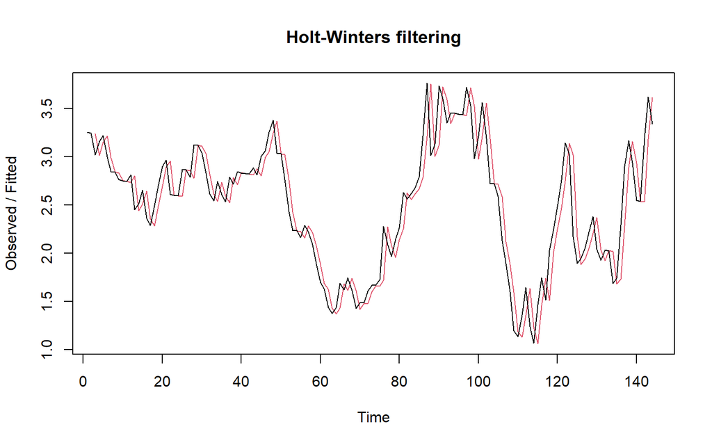

```r
plot(des.opt)
```

```r
#ramalan
ramalandesopt<- forecast(des.opt, h=n_test)
ramalandesopt
```

```
##     Point Forecast    Lo 80    Hi 80      Lo 95    Hi 95
## 145        3.33527 3.004244 3.666296 2.82901018 3.841530
## 146        3.32822 2.860079 3.796361 2.61226049 4.044180
## 147        3.32117 2.747817 3.894523 2.44430226 4.198038
## 148        3.31412 2.652069 3.976171 2.30160035 4.326640
## 149        3.30707 2.566874 4.047266 2.17503862 4.439101
## 150        3.30002 2.489176 4.110864 2.05994175 4.540098
## 151        3.29297 2.417159 4.168781 1.95353241 4.632408
## 152        3.28592 2.349638 4.222202 1.85400098 4.717839
## 153        3.27887 2.285793 4.271947 1.76009053 4.797649
## 154        3.27182 2.225025 4.318615 1.67088587 4.872754
## 155        3.26477 2.166883 4.362657 1.58569612 4.943844
## 156        3.25772 2.111014 4.404426 1.50398452 5.011455
## 157        3.25067 2.057141 4.444199 1.42532424 5.076016
## 158        3.24362 2.005036 4.482204 1.34936919 5.137871
```

[output cut: 22 more lines]

Selanjutnya akan dilakukan perhitungan akurasi pada data latih maupun data uji dengan ukuran akurasi SSE, MSE dan MAPE.

#### Akurasi Data Latih

```r
#Akurasi Data Training
ssedes.train1<-des.1$SSE
msedes.train1<-ssedes.train1/length(train.ts)
sisaandes1<-ramalandes1$residuals
head(sisaandes1)
```

```
## Time Series:
## Start = 1
## End = 6
## Frequency = 1
## [1]         NA         NA -0.2202900 -0.0234004  0.0628873 -0.1587380
```

```r
mapedes.train1 <- sum(abs(sisaandes1[3:length(train.ts)]/train.ts[3:length(train.ts)])
                      *100)/length(train.ts)

akurasides.1 <- matrix(c(ssedes.train1,msedes.train1,mapedes.train1))
row.names(akurasides.1)<- c("SSE", "MSE", "MAPE")
colnames(akurasides.1) <- c("Akurasi lamda=0.2 dan gamma=0.2")
akurasides.1
```

```
##      Akurasi lamda=0.2 dan gamma=0.2
## SSE                       29.6855335
## MSE                        0.2061495
## MAPE                      15.7552108
```

```r
ssedes.train2<-des.2$SSE
msedes.train2<-ssedes.train2/length(train.ts)
sisaandes2<-ramalandes2$residuals
head(sisaandes2)
```

```
## Time Series:
## Start = 1
## End = 6
## Frequency = 1
## [1]         NA         NA -0.2202900  0.0955562  0.1325346 -0.1646703
```

```r
mapedes.train2 <- sum(abs(sisaandes2[3:length(train.ts)]/train.ts[3:length(train.ts)])
                      *100)/length(train.ts)

akurasides.2 <- matrix(c(ssedes.train2,msedes.train2,mapedes.train2))
row.names(akurasides.2)<- c("SSE", "MSE", "MAPE")
colnames(akurasides.2) <- c("Akurasi lamda=0.6 dan gamma=0.3")
akurasides.2
```

```
##      Akurasi lamda=0.6 dan gamma=0.3
## SSE                      12.44013751
## MSE                       0.08638984
## MAPE                      9.23763725
```

#### Akurasi Data Uji

```r
#Akurasi Data Testing
selisihdes1<-ramalandes1$mean-testing$CPIAUCSL_PC1
selisihdes1
```

```
## Time Series:
## Start = 145
## End = 180
## Frequency = 1
##  [1]  0.41545908  0.32219432  0.28327955  0.24322479  0.85062003  1.29377527
##  [7]  0.88254051  0.41766575 -0.56233902 -0.05571378  1.07073146  1.18562670
## [13]  0.62028194  1.11571717  1.45094241  1.36991765  1.12138289  1.03182813
## [19]  1.22377336  1.51676860  3.54616384  4.26679908  3.81932432  3.37893956
## [25]  3.94204479  3.71245003  3.44940527  3.76958051  3.76750575  3.89952098
## [31]  4.38929622  4.92463146  4.10314670  3.44117194  2.79349717  3.17285241
```

```r
SSEtestingdes1<-sum(selisihdes1^2)
MSEtestingdes1<-SSEtestingdes1/length(testing$CPIAUCSL_PC1)
MAPEtestingdes1<-sum(abs(selisihdes1/testing$CPIAUCSL_PC1)*100)/length(testing$CPIAUCSL_PC1)

selisihdes2<-ramalandes2$mean-testing$CPIAUCSL_PC1
selisihdes2
```

```
## Time Series:
## Start = 145
## End = 180
## Frequency = 1
##  [1] 0.745287490 0.682300312 0.673663133 0.663885955 1.301558776 1.774991598
##  [7] 1.394034419 0.959437241 0.009710063 0.546612884 1.703335706 1.848508527
## [13] 1.313441349 1.839154170 2.204656992 2.153909813 1.935652635 1.876375457
## [19] 2.098598278 2.421871100 4.481543921 5.232456743 4.815259564 4.405152386
## [25] 4.998535207 4.799218029 4.566450851 4.916903672 4.945106494 5.107399315
## [31] 5.627452137 6.193064958 5.401857780 4.770160601 4.152763423 4.562396245
```

```r
SSEtestingdes2<-sum(selisihdes2^2)
MSEtestingdes2<-SSEtestingdes2/length(testing$CPIAUCSL_PC1)
MAPEtestingdes2<-sum(abs(selisihdes2/testing$CPIAUCSL_PC1)*100)/length(testing$CPIAUCSL_PC1)

selisihdesopt<-ramalandesopt$mean-testing$CPIAUCSL_PC1
selisihdesopt
```

```
## Time Series:
## Start = 145
## End = 180
## Frequency = 1
##  [1]  0.49040  0.27519  0.11433 -0.04767  0.43778  0.75899  0.22581 -0.36101
##  [9] -1.46296 -1.07828 -0.07378 -0.08083 -0.76812 -0.39463 -0.18135 -0.38432
## [17] -0.75480 -0.96630 -0.89630 -0.72525  1.18220  1.78089  1.21147  0.64914
## [25]  1.09030  0.73876  0.35377  0.55200  0.42798  0.43805  0.80588  1.21927
## [33]  0.27584 -0.50808 -1.27770 -1.02029
```

```r
SSEtestingdesopt<-sum(selisihdesopt^2)
MSEtestingdesopt<-SSEtestingdesopt/length(testing$CPIAUCSL_PC1)
MAPEtestingdesopt<-sum(abs(selisihdesopt/testing$CPIAUCSL_PC1)*100)/length(testing$CPIAUCSL_PC1)

akurasitestingdes <-
  matrix(c(SSEtestingdes1,MSEtestingdes1,MAPEtestingdes1,SSEtestingdes2,MSEtestingdes2,
           MAPEtestingdes2,SSEtestingdesopt,MSEtestingdesopt,MAPEtestingdesopt),
         nrow=3,ncol=3)
row.names(akurasitestingdes)<- c("SSE", "MSE", "MAPE")
colnames(akurasitestingdes) <- c("des ske1","des ske2","des opt")
akurasitestingdes
```

```
##        des ske1  des ske2    des opt
## SSE  250.051753 442.04431 22.4960931
## MSE    6.945882  12.27901  0.6248915
## MAPE  83.997811 113.47251 24.4653249
```

#### Perbandingan SES dan DES

```r
MSEfull <-
  matrix(c(MSEtesting1,MSEtesting2,MSEtestingopt,MSEtestingdes1,MSEtestingdes2,
           MSEtestingdesopt),nrow=3,ncol=2)
row.names(MSEfull)<- c("ske 1", "ske 2", "ske opt")
colnames(MSEfull) <- c("ses","des")
MSEfull
```

```
##               ses        des
## ske 1   0.6848595  6.9458820
## ske 2   0.6875856 12.2790087
## ske opt 0.6761040  0.6248915
```

## Pemulusan Data Musiman

Pemulusan data musiman berikut menggunakan data CPI yang sama dengan analisis sebelumnya (`data1`).

Data yang digunakan untuk pemulusan musiman adalah data CPI yang sama dengan bagian sebelumnya (`data1`), dengan frequency bulanan (12 periode per tahun).

```r
#Menggunakan data CPI yang sama (data1), bukan dataset lain
data3 <- data1
data3.ts <- ts(data3$CPIAUCSL_PC1, frequency = 12)
```

Selanjutnya melakukan pembagian data dan mengubahnya menjadi data deret waktu, dengan perbandingan 80% data latih dan 20% data uji, sama seperti pembagian pada bagian sebelumnya.

```r
#membagi data menjadi training dan testing
n3 <- nrow(data3)
n3_train <- floor(0.8 * n3)

training <- data3[1:n3_train, "CPIAUCSL_PC1"]
testing  <- data3[(n3_train+1):n3, "CPIAUCSL_PC1"]
training.ts <- ts(training, frequency = 12)
testing.ts  <- ts(testing, frequency = 12)

# jumlah periode uji disimpan sebagai angka tetap
# (testing.ts akan diubah jadi data.frame di bagian akurasi nanti)
n_test_w <- length(testing.ts)
```

Kemudian akan dilakukan eskplorasi dengan plot data deret waktu sebagai berikut.

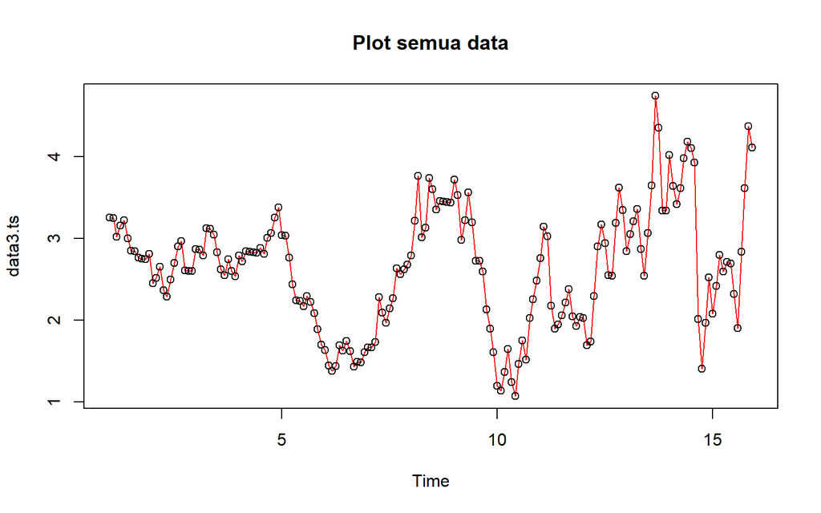

```r
#Membuat plot time series
plot(data3.ts, col="red",main="Plot semua data")
points(data3.ts)
```

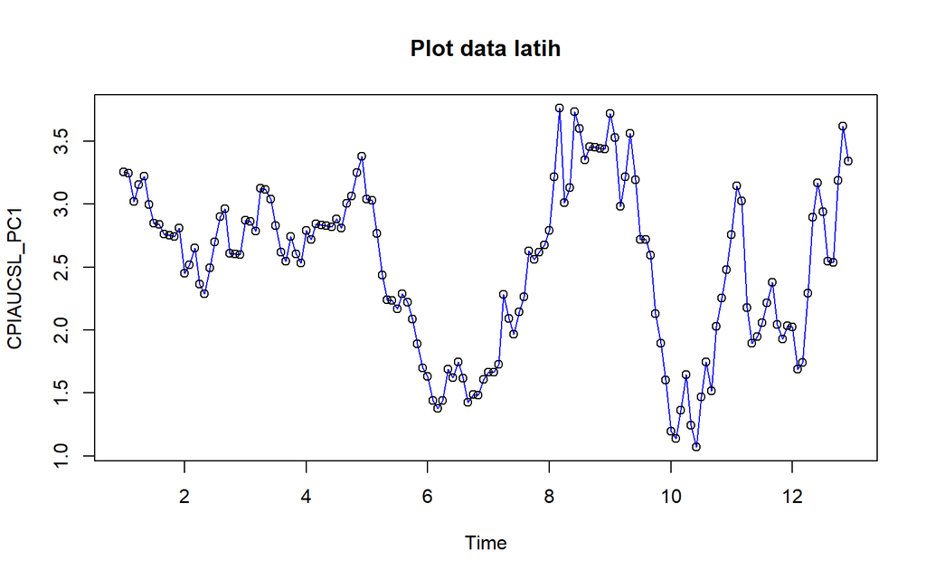

```r
plot(training.ts, col="blue",main="Plot data latih")
points(training.ts)
```

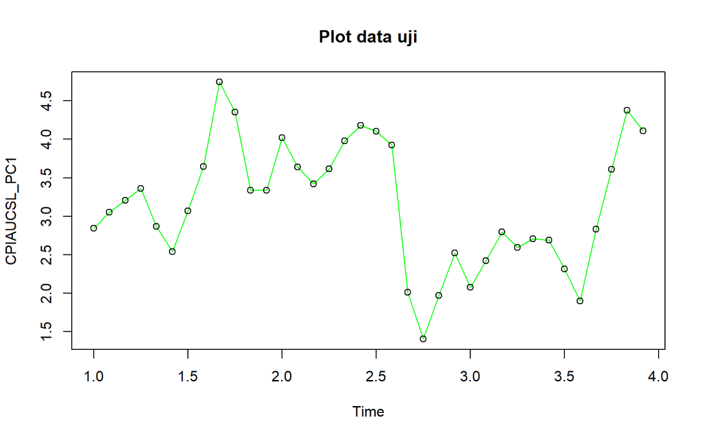

```r
plot(testing.ts, col="green",main="Plot data uji")
points(testing.ts)
```

Metode Holt-Winter untuk peramalan data musiman menggunakan tiga persamaan pemulusan yang terdiri atas persamaan untuk level $(L_t)$, trend $(B_t)$, dan komponen seasonal / musiman $(S_t)$ dengan parameter pemulusan berupa $\alpha$, $\beta$, dan $\gamma$. Metode Holt-Winter musiman terbagi menjadi dua, yaitu metode aditif dan metode multiplikatif. Perbedaan persamaan dan contoh datanya adalah sebagai berikut.

[figure not shown]

Pemulusan data musiman dengan metode Winter dilakukan menggunakan fungsi `HoltWinters()` dengan memasukkan argumen tambahan, yaitu `gamma()` dan `seasonal()` . Arguman `seasonal()` diinisialisasi menyesuaikan jenis musiman, aditif atau multiplikatif.

### Winter Aditif

Perhitungan dengan model aditif dilakukan jika plot data asli menunjukkan fluktuasi musiman yang relatif stabil (konstan).

#### Pemulusan

```r
#Pemulusan dengan winter aditif
winter1 <- HoltWinters(training.ts,alpha=0.2,beta=0.1,gamma=0.1,seasonal = "additive")
winter1$fitted
```

```
##            xhat    level         trend        season
## Jan  2 2.780447 2.899036 -2.939526e-02 -0.0891936806
## Feb  2 2.746992 2.803748 -3.598461e-02 -0.0207711806
## Mar  2 2.785306 2.721509 -4.061004e-02  0.1044071528
## Apr  2 2.425467 2.654193 -4.328056e-02 -0.1854461806
## May  2 2.304691 2.598698 -4.450209e-02 -0.2495040972
## Jun  2 2.477742 2.550955 -4.482612e-02 -0.0283870139
## Jul  2 2.455043 2.509541 -4.448496e-02 -0.0100128472
## Aug  2 2.522060 2.513839 -3.960662e-02  0.0478275694
## Sep  2 2.534589 2.549930 -3.203682e-02  0.0166950694
## Oct  2 2.633964 2.604080 -2.341819e-02  0.0533025694
## Nov  2 2.669372 2.575847 -2.389968e-02  0.1174246528
## Dec  2 2.757046 2.538621 -2.523232e-02  0.2436579861
## Jan  3 2.337483 2.481459 -2.842525e-02 -0.1155510724
## Feb  3 2.502668 2.559699 -1.775870e-02 -0.0392729255
## Mar  3 2.697178 2.614005 -1.055226e-02  0.0937250937
## Apr  3 2.422378 2.621461 -8.751418e-03 -0.1903323165
## May  3 2.507735 2.753234  5.301031e-03 -0.2508002053
## Jun  3 2.871213 2.880716  1.751913e-02 -0.0270223775
## Jul  3 2.962960 2.932513  2.094687e-02  0.0095005254
## Aug  3 3.023304 2.926906  1.829146e-02  0.0781067636
## Sep  3 2.925370 2.864026  1.017438e-02  0.0511695702
## Oct  3 2.852116 2.798169  2.571177e-03  0.0513766255
## Nov  3 2.891688 2.779179  4.150471e-04  0.1120941053
## Dec  3 2.947487 2.721950 -5.349307e-03  0.2308862668
## Jan  4 2.546882 2.633433 -1.366605e-02 -0.0728849035
## Feb  4 2.649294 2.668531 -8.789695e-03 -0.0104471458
## Mar  4 2.766782 2.673288 -7.434975e-03  0.1009284566
## Apr  4 2.541266 2.681281 -5.892211e-03 -0.1341225199
## May  4 2.531678 2.733670 -6.413656e-05 -0.2019278194
## Jun  4 2.785221 2.792688  5.844112e-03 -0.0133114252
## Jul  4 2.811241 2.805792  6.570101e-03 -0.0011210942
## Aug  4 2.880437 2.826786  8.012483e-03  0.0456384520
## Sep  4 2.848577 2.821171  6.649748e-03  0.0207567458
## Oct  4 2.911541 2.859019  9.769600e-03  0.0427521074
## Nov  4 3.000672 2.898859  1.277658e-02  0.0890366887
## Dec  4 3.177563 2.962119  1.782494e-02  0.1976193051
## Jan  5 2.988666 3.020195  2.185008e-02 -0.0533794955
## Feb  5 3.069751 3.051940  2.283957e-02 -0.0050282643
## Mar  5 3.196471 3.067281  2.208974e-02  0.1070995116
```

[output cut: 78 more lines]

```
## Oct 11 2.326993 2.268448  2.047463e-02  0.0380700405
## Nov 11 2.318444 2.231912  1.477357e-02  0.0717579852
## Dec 11 2.317436 2.168671  6.972089e-03  0.1417924911
## Jan 12 2.138031 2.119196  1.327376e-03  0.0175072468
## Feb 12 2.163251 2.098175 -9.074380e-04  0.0659832802
## Mar 12 2.100682 2.002308 -1.040346e-02  0.1087775306
## Apr 12 1.830209 1.919784 -1.761549e-02 -0.0719596462
## May 12 1.844290 1.994643 -8.368069e-03 -0.1419841507
## Jun 12 2.152395 2.196968  1.270132e-02 -0.0572747628
## Jul 12 2.418828 2.412725  3.300682e-02 -0.0269037592
## Aug 12 2.619019 2.549882  4.342187e-02  0.0257146295
## Sep 12 2.648975 2.578986  4.199010e-02  0.0279986542
## Oct 12 2.654075 2.599015  3.979400e-02  0.0152658052
## Nov 12 2.837259 2.746176  5.053070e-02  0.0405520761
## Dec 12 3.139011 2.953579  6.621791e-02  0.1192136362
```

```r
xhat1 <- winter1$fitted[,2]

winter1.opt<- HoltWinters(training.ts, alpha= NULL,  beta = NULL, gamma = NULL, seasonal = "additive")
winter1.opt
```

```
## Holt-Winters exponential smoothing with trend and additive seasonal component.
##
## Call:
## HoltWinters(x = training.ts, alpha = NULL, beta = NULL, gamma = NULL,     seasonal = "additive")
##
## Smoothing parameters:
##  alpha: 0.9181699
##  beta : 0.004564975
##  gamma: 1
##
## Coefficients:
##             [,1]
## a    3.193640601
## b   -0.013775002
## s1   0.097623014
## s2   0.024126886
## s3   0.057764578
## s4  -0.024298618
## s5  -0.110694397
## s6  -0.087233759
## s7  -0.048338858
## s8   0.004365971
## s9   0.046328400
## s10  0.085930680
## s11  0.110704725
## s12  0.148679399
```

```r
winter1.opt$fitted
```

```
##            xhat    level       trend       season
## Jan  2 2.780447 2.899036 -0.02939526 -0.089193681
## Feb  2 2.515587 2.567134 -0.03077620 -0.020771181
## Mar  2 2.610112 2.536480 -0.03077564  0.104407153
## Apr  2 2.327916 2.543963 -0.03060099 -0.185446181
## May  2 2.266899 2.546852 -0.03044811 -0.249504097
## Jun  2 2.477483 2.536227 -0.03035761 -0.028387014
## Jul  2 2.481472 2.521770 -0.03028503 -0.010012847
## Aug  2 2.709630 2.691176 -0.02937345  0.047827569
## Sep  2 2.825221 2.837099 -0.02857322  0.016695069
## Oct  2 2.962662 2.937344 -0.02798517  0.053302569
## Nov  2 2.673416 2.585455 -0.02946378  0.117424653
## Dec  2 2.704997 2.491099 -0.02976002  0.243657986
## Jan  3 2.216182 2.362547 -0.03021100 -0.116154045
## Feb  3 2.885168 2.933396 -0.02746717 -0.020760270
## Mar  3 2.965822 2.885565 -0.02756013  0.107816869
## Apr  3 2.483248 2.694018 -0.02830873 -0.182461505
## May  3 2.981591 3.254947 -0.02561887 -0.247737327
## Jun  3 3.303148 3.355163 -0.02504444 -0.026969937
## Jul  3 3.072538 3.090891 -0.02613651  0.007784222
## Aug  3 2.878535 2.842237 -0.02715229  0.063450589
## Sep  3 2.575293 2.575364 -0.02824661  0.028175735
## Oct  3 2.515558 2.519496 -0.02837271  0.024435213
## Nov  3 2.785383 2.701156 -0.02741391  0.111641254
## Dec  3 2.713392 2.506715 -0.02817639  0.234853331
## Jan  4 2.220145 2.311669 -0.02893814 -0.062585711
## Feb  4 2.757475 2.806597 -0.02654671 -0.022575121
## Mar  4 2.809400 2.742915 -0.02671623  0.093201853
## Apr  4 2.591375 2.747893 -0.02657154 -0.129946839
## May  4 2.680789 2.942872 -0.02556017 -0.236522558
## Jun  4 2.978403 3.051641 -0.02494696 -0.048290631
## Jul  4 2.844997 2.882648 -0.02560453 -0.012047178
## Aug  4 2.908910 2.892268 -0.02544373  0.042085927
## Sep  4 2.777985 2.778120 -0.02584866  0.025714023
## Oct  4 2.978570 2.960314 -0.02489895  0.043153983
## Nov  4 3.084123 3.011918 -0.02454972  0.096755257
## Dec  4 3.338648 3.142508 -0.02384151  0.219981383
## Jan  5 3.115981 3.155551 -0.02367313 -0.015897094
## Feb  5 3.010523 3.060407 -0.02399940 -0.025884763
## Mar  5 3.128484 3.056366 -0.02390829  0.096026598
```

[output cut: 78 more lines]

```
## Oct 11 2.366492 2.329033 -0.01894316  0.056402589
## Nov 11 2.077225 2.012096 -0.02030349  0.085432659
## Dec 11 2.007801 1.855118 -0.02092741  0.173610205
## Jan 12 1.928125 1.859348 -0.02081257  0.089590186
## Feb 12 1.954134 1.928667 -0.02040112  0.045867821
## Mar 12 1.697052 1.664323 -0.02151471  0.054243590
## Apr 12 1.578227 1.682315 -0.02133436 -0.082754241
## May 12 2.124574 2.316879 -0.01834020 -0.173964310
## Jun 12 2.882811 3.008454 -0.01509946 -0.110543800
## Jul 12 3.215215 3.254904 -0.01390549 -0.025783637
## Aug 12 3.015529 2.987919 -0.01506079  0.042670548
## Sep 12 2.575328 2.543064 -0.01702279  0.049287255
## Oct 12 2.505512 2.492842 -0.01717435  0.029844438
## Nov 12 3.163930 3.104979 -0.01430155  0.073251855
## Dec 12 3.674384 3.510915 -0.01238318  0.175852274
```

```r
xhat1.opt <- winter1.opt$fitted[,2]
```

#### Peramalan

```r
#Forecast
forecast1 <- predict(winter1, n.ahead = n_test_w)
forecast1.opt <- predict(winter1.opt, n.ahead = n_test_w)
```

#### Plot Deret Waktu

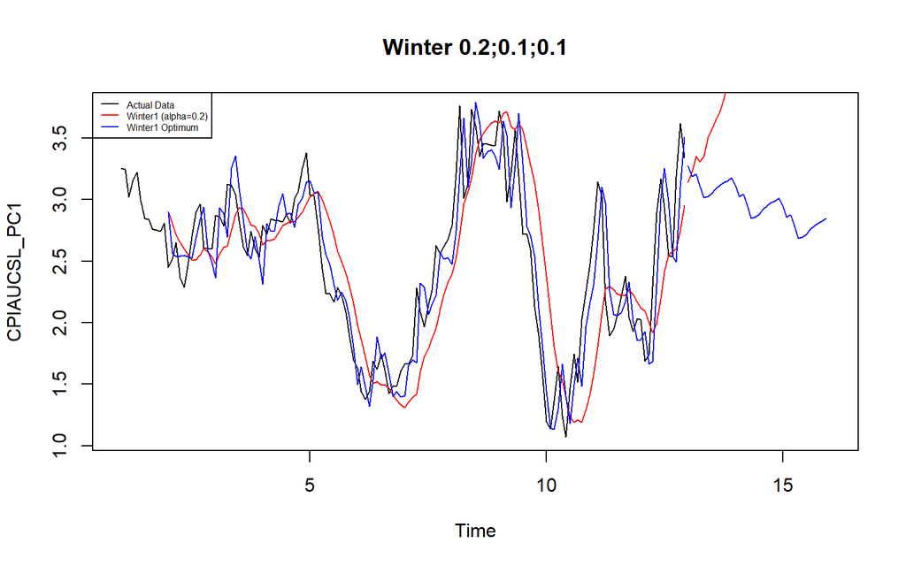

```r
#Plot time series
plot(training.ts,main="Winter 0.2;0.1;0.1",type="l",col="black",
     xlim=c(start(training.ts)[1], end(training.ts)[1] + n_test_w/12 + 1),pch=12)
lines(xhat1,type="l",col="red")
lines(xhat1.opt,type="l",col="blue")
lines(forecast1,type="l",col="red")
lines(forecast1.opt,type="l",col="blue")
legend("topleft",c("Actual Data","Winter1 (alpha=0.2)","Winter1 Optimum"),cex=0.5,
       col=c("black","red","blue"),lty=1)
```

#### Akurasi Data Latih

```r
#Akurasi data training
SSE1<-winter1$SSE
MSE1<-winter1$SSE/length(training.ts)
RMSE1<-sqrt(MSE1)
akurasi1 <- matrix(c(SSE1,MSE1,RMSE1))
row.names(akurasi1)<- c("SSE", "MSE", "RMSE")
colnames(akurasi1) <- c("Akurasi")
akurasi1
```

```
##         Akurasi
## SSE  33.0161135
## MSE   0.2292786
## RMSE  0.4788304
```

```r
SSE1.opt<-winter1.opt$SSE
MSE1.opt<-winter1.opt$SSE/length(training.ts)
RMSE1.opt<-sqrt(MSE1.opt)
akurasi1.opt <- matrix(c(SSE1.opt,MSE1.opt,RMSE1.opt))
row.names(akurasi1.opt)<- c("SSE1.opt", "MSE1.opt", "RMSE1.opt")
colnames(akurasi1.opt) <- c("Akurasi")
akurasi1.opt
```

```
##               Akurasi
## SSE1.opt  11.81507694
## MSE1.opt   0.08204915
## RMSE1.opt  0.28644222
```

```r
akurasi1.train = data.frame(Model_Winter = c("Winter 1","Winter1 optimal"),
                            Nilai_SSE=c(SSE1,SSE1.opt),
                            Nilai_MSE=c(MSE1,MSE1.opt),Nilai_RMSE=c(RMSE1,RMSE1.opt))
akurasi1.train
```

```
##      Model_Winter Nilai_SSE  Nilai_MSE Nilai_RMSE
## 1        Winter 1  33.01611 0.22927857  0.4788304
## 2 Winter1 optimal  11.81508 0.08204915  0.2864422
```

#### Akurasi Data Uji

```r
#Akurasi Data Testing
forecast1<-data.frame(forecast1)
testing.ts<-data.frame(testing.ts)
selisih1<-forecast1-testing.ts
SSEtesting1<-sum(selisih1^2)
MSEtesting1<-SSEtesting1/nrow(testing.ts)

forecast1.opt<-data.frame(forecast1.opt)
selisih1.opt<-forecast1.opt-testing.ts
SSEtesting1.opt<-sum(selisih1.opt^2)
MSEtesting1.opt<-SSEtesting1.opt/nrow(testing.ts)
```

```r
akurasi_testing <- data.frame(
  Model = c("Model1", "Model Optimum"),
  SSE   = c(SSEtesting1, SSEtesting1.opt),
  MSE   = c(MSEtesting1, MSEtesting1.opt)
)

akurasi_testing
```

```
##           Model      SSE       MSE
## 1        Model1 106.8854 2.9690390
## 2 Model Optimum  23.4596 0.6516556
```

### Winter Multiplikatif

Model multiplikatif digunakan cocok digunakan jika plot data asli menunjukkan fluktuasi musiman yang bervariasi.

#### Pemulusan

```r
#Pemulusan dengan winter multiplikatif
winter2 <- HoltWinters(training.ts,alpha=0.2,beta=0.1,gamma=0.3,seasonal = "multiplicative")
winter2$fitted
```

```
##            xhat    level         trend    season
## Jan  2 2.767435 2.899036 -0.0293952593 0.9643836
## Feb  2 2.743833 2.804013 -0.0359580995 0.9912495
## Mar  2 2.790159 2.722029 -0.0405606261 1.0405340
## Apr  2 2.420729 2.654871 -0.0432204017 0.9268961
## May  2 2.302614 2.599494 -0.0444360417 0.9011983
## Jun  2 2.477160 2.551924 -0.0447494917 0.9880288
## Jul  2 2.464855 2.510745 -0.0443924223 0.9993927
## Aug  2 2.521577 2.513202 -0.0397074696 1.0194393
## Sep  2 2.535432 2.547844 -0.0322725478 1.0078952
## Oct  2 2.631477 2.600915 -0.0237381698 1.0210698
## Nov  2 2.664041 2.572948 -0.0241610070 1.0452189
## Dec  2 2.749568 2.537058 -0.0253339778 1.0946939
## Jan  3 2.301824 2.483923 -0.0281140873 0.9372977
## Feb  3 2.487320 2.577218 -0.0159730922 0.9711369
## Mar  3 2.704091 2.638612 -0.0082363823 1.0280245
## Apr  3 2.433209 2.646549 -0.0066191268 0.9216946
## May  3 2.518227 2.790042  0.0083921663 0.8998700
## Jun  3 2.923238 2.931879  0.0217365987 0.9897150
## Jul  3 3.067172 2.977736  0.0241486566 1.0217488
## Aug  3 3.139042 2.955497  0.0195099026 1.0551375
## Sep  3 3.023073 2.876140  0.0096232002 1.0475817
## Oct  3 2.848294 2.794532  0.0005000414 1.0190562
## Nov  3 2.882398 2.774624 -0.0015407555 1.0394200
## Dec  3 2.929482 2.719413 -0.0069077448 1.0799911
## Jan  4 2.599056 2.638832 -0.0142750594 0.9902838
## Feb  4 2.666935 2.663262 -0.0104045816 1.0053067
## Mar  4 2.747779 2.662823 -0.0094079742 1.0355630
## Apr  4 2.614348 2.671983 -0.0075511844 0.9812026
## May  4 2.567886 2.708933 -0.0031010891 0.9490190
## Jun  4 2.760983 2.760458  0.0023614758 0.9993354
## Jul  4 2.785467 2.774935  0.0035730226 1.0025047
## Aug  4 2.836122 2.798037  0.0055259890 1.0116132
## Sep  4 2.822251 2.798854  0.0050550258 1.0065419
## Oct  4 2.877477 2.840135  0.0086776975 1.0100617
## Nov  4 2.940553 2.885328  0.0123292159 1.0148034
## Dec  4 3.108193 2.959253  0.0184887820 1.0438086
## Jan  5 3.076334 3.029596  0.0236741644 1.0075538
## Feb  5 3.098743 3.045688  0.0229160185 1.0098217
## Mar  5 3.213037 3.055437  0.0215992822 1.0441985
```

[output cut: 78 more lines]

```
## Oct 11 2.521335 2.186198  0.0117417947 1.1471357
## Nov 11 2.395926 2.114359  0.0033836647 1.1313586
## Dec 11 2.255096 2.035088 -0.0048817257 1.1107717
## Jan 12 2.133782 1.990613 -0.0088410651 1.0767041
## Feb 12 2.102123 1.961805 -0.0108377559 1.0774770
## Mar 12 1.974268 1.874182 -0.0185163004 1.0639134
## Apr 12 1.806310 1.811642 -0.0229186835 1.0098320
## May 12 1.779610 1.885030 -0.0132879754 0.9507770
## Jun 12 2.016602 2.106950  0.0102327946 0.9524932
## Jul 12 2.486416 2.358879  0.0344023702 1.0389152
## Aug 12 2.788399 2.480519  0.0431261605 1.1049092
## Sep 12 2.748609 2.480027  0.0387643777 1.0912410
## Oct 12 2.748553 2.480406  0.0349258374 1.0927197
## Nov 12 2.840486 2.596296  0.0430222766 1.0762193
## Dec 12 3.081488 2.784481  0.0575385433 1.0842597
```

```r
xhat2 <- winter2$fitted[,2]

winter2.opt<- HoltWinters(training.ts, alpha= NULL,  beta = NULL, gamma = NULL, seasonal = "multiplicative")
winter2.opt$fitted
```

```
##            xhat    level       trend    season
## Jan  2 2.767435 2.899036 -0.02939526 0.9643836
## Feb  2 2.502313 2.554185 -0.02978190 0.9912495
## Mar  2 2.609284 2.537405 -0.02976597 1.0405340
## Apr  2 2.333167 2.546901 -0.02971785 0.9268961
## May  2 2.270919 2.549566 -0.02967816 0.9011983
## Jun  2 2.478941 2.538632 -0.02965518 0.9880288
## Jul  2 2.493256 2.524407 -0.02963627 0.9993927
## Aug  2 2.715021 2.692643 -0.02939374 1.0194393
## Sep  2 2.831203 2.838205 -0.02917931 1.0078952
## Oct  2 2.969389 2.937138 -0.02902228 1.0210698
## Nov  2 2.655074 2.569646 -0.02943713 1.0452189
## Dec  2 2.695769 2.492074 -0.02949613 1.0946939
## Jan  3 2.251773 2.376192 -0.02960201 0.9595938
## Feb  3 2.912803 2.966753 -0.02884190 0.9914537
## Mar  3 2.978511 2.889611 -0.02890110 1.0411791
## Apr  3 2.462138 2.684087 -0.02911758 0.9273695
## May  3 2.987312 3.342113 -0.02827537 0.9014659
## Jun  3 3.385606 3.453889 -0.02810371 0.9882717
## Jul  3 3.070801 3.092126 -0.02851267 1.0023461
## Aug  3 2.865645 2.832846 -0.02879551 1.0219664
## Sep  3 2.566056 2.570579 -0.02908167 1.0096631
## Oct  3 2.531579 2.521649 -0.02910600 1.0156612
## Nov  3 2.783383 2.693896 -0.02885920 1.0444070
## Dec  3 2.700346 2.499433 -0.02906218 1.0930934
## Jan  4 2.218617 2.322008 -0.02924402 0.9676605
## Feb  4 2.806467 2.861110 -0.02854742 0.9907873
## Mar  4 2.821533 2.745784 -0.02865378 1.0384238
## Apr  4 2.533228 2.737856 -0.02862838 0.9350372
## May  4 2.698732 3.017093 -0.02825104 0.9029359
## Jun  4 3.047808 3.125502 -0.02808354 0.9839832
## Jul  4 2.845314 2.876338 -0.02835451 0.9990625
## Aug  4 2.908364 2.884593 -0.02830964 1.0182337
## Sep  4 2.762741 2.765587 -0.02842080 1.0093436
## Oct  4 2.994363 2.967494 -0.02813850 1.0187141
## Nov  4 3.098852 3.003080 -0.02806039 1.0416242
## Dec  4 3.368417 3.117369 -0.02788592 1.0902847
## Jan  5 2.995212 3.098656 -0.02787467 0.9753906
## Feb  5 3.052960 3.113092 -0.02782282 0.9895280
## Mar  5 3.154976 3.065159 -0.02784746 1.0387399
```

[output cut: 78 more lines]

```
## Oct 11 2.371076 2.348835 -0.02606943 1.0207985
## Nov 11 2.060494 2.012801 -0.02644934 1.0373260
## Dec 11 1.980613 1.863906 -0.02659942 1.0779985
## Jan 12 1.850273 1.885986 -0.02653976 0.9950666
## Feb 12 1.989781 2.029497 -0.02633133 0.9933181
## Mar 12 1.734345 1.711536 -0.02668877 1.0293784
## Apr 12 1.586983 1.690203 -0.02668221 0.9539906
## May 12 2.128393 2.374553 -0.02581072 0.9061839
## Jun 12 3.011178 3.164938 -0.02481033 0.9589348
## Jul 12 3.285228 3.297013 -0.02461804 1.0039218
## Aug 12 2.984473 2.941407 -0.02502372 1.0233472
## Sep 12 2.511431 2.505822 -0.02552693 1.0125531
## Oct 12 2.517056 2.506632 -0.02549465 1.0144768
## Nov 12 3.202025 3.119696 -0.02471199 1.0345856
## Dec 12 3.734435 3.484872 -0.02423412 1.0791174
```

```r
xhat2.opt <- winter2.opt$fitted[,2]
```

#### Peramalan

```r
#Forecast
forecast2 <- predict(winter2, n.ahead = n_test_w)
forecast2.opt <- predict(winter2.opt, n.ahead = n_test_w)
```

#### Plot Deret Waktu

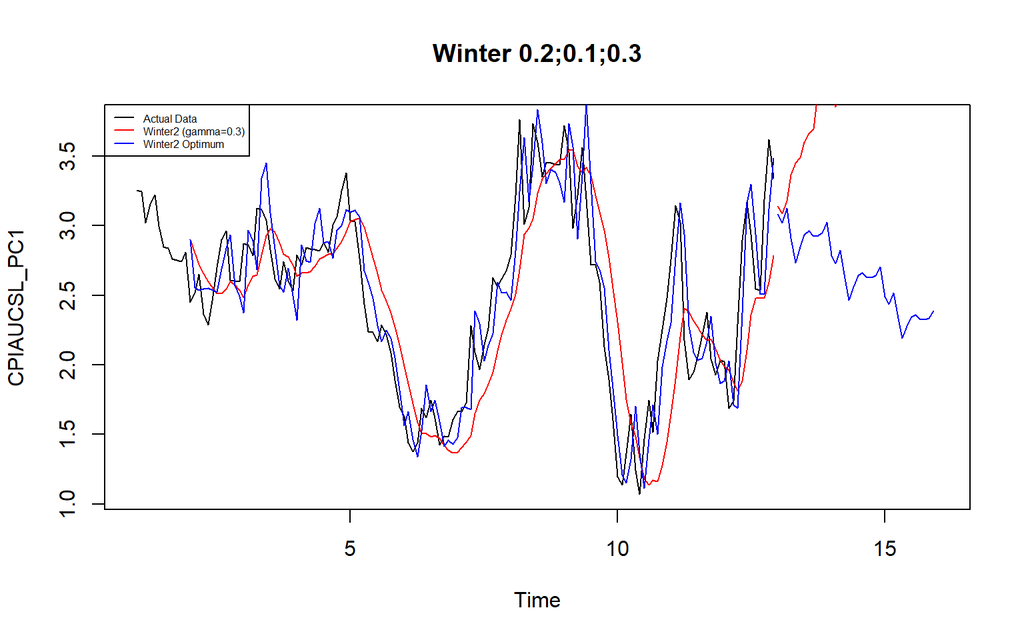

```r
#Plot time series
plot(training.ts,main="Winter 0.2;0.1;0.3",type="l",col="black",
     xlim=c(start(training.ts)[1], end(training.ts)[1] + n_test_w/12 + 1),pch=12)
lines(xhat2,type="l",col="red")
lines(xhat2.opt,type="l",col="blue")
lines(forecast2,type="l",col="red")
lines(forecast2.opt,type="l",col="blue")
legend("topleft",c("Actual Data","Winter2 (gamma=0.3)","Winter2 Optimum"),cex=0.5,
       col=c("black","red","blue"),lty=1)
```

#### Akurasi Data Latih

```r
#Akurasi data training
SSE2<-winter2$SSE
MSE2<-winter2$SSE/length(training.ts)
RMSE2<-sqrt(MSE2)
akurasi1 <- matrix(c(SSE2,MSE2,RMSE2))
row.names(akurasi1)<- c("SSE2", "MSE2", "RMSE2")
colnames(akurasi1) <- c("Akurasi lamda=0.2")
akurasi1
```

```
##       Akurasi lamda=0.2
## SSE2         33.1628739
## MSE2          0.2302977
## RMSE2         0.4798935
```

```r
SSE2.opt<-winter2.opt$SSE
MSE2.opt<-winter2.opt$SSE/length(training.ts)
RMSE2.opt<-sqrt(MSE2.opt)
akurasi1.opt <- matrix(c(SSE2.opt,MSE2.opt,RMSE2.opt))
row.names(akurasi1.opt)<- c("SSE2.opt", "MSE2.opt", "RMSE2.opt")
colnames(akurasi1.opt) <- c("Akurasi")
akurasi1.opt
```

```
##               Akurasi
## SSE2.opt  11.77838246
## MSE2.opt   0.08179432
## RMSE2.opt  0.28599707
```

```r
akurasi2.train = data.frame(Model_Winter = c("Winter 1","winter2 optimal"),
                            Nilai_SSE=c(SSE2,SSE2.opt),
                            Nilai_MSE=c(MSE2,MSE2.opt),Nilai_RMSE=c(RMSE2,RMSE2.opt))
akurasi2.train
```

```
##      Model_Winter Nilai_SSE  Nilai_MSE Nilai_RMSE
## 1        Winter 1  33.16287 0.23029774  0.4798935
## 2 winter2 optimal  11.77838 0.08179432  0.2859971
```

#### Akurasi Data Uji

```r
#Akurasi Data Testing
forecast2<-data.frame(forecast2)
testing.ts<-data.frame(testing.ts)
selisih2<-forecast2-testing.ts
SSEtesting2<-sum(selisih2^2)
MSEtesting2<-SSEtesting2/nrow(testing.ts)

forecast2.opt<-data.frame(forecast2.opt)
selisih2.opt<-forecast2.opt-testing.ts
SSEtesting2.opt<-sum(selisih2.opt^2)
MSEtesting2.opt<-SSEtesting2.opt/nrow(testing.ts)
```

```r
# Atau rapikan dalam tabel
akurasi_testing2 <- data.frame(
  Model = c("Model2", "Model2 Optimal"),
  SSE   = c(SSEtesting2, SSEtesting2.opt),
  MSE   = c(MSEtesting2, MSEtesting2.opt)
)

akurasi_testing2
```

```
##            Model       SSE       MSE
## 1         Model2 104.50783 2.9029952
## 2 Model2 Optimal  31.10595 0.8640541
```